# Default Payment Classification dataset using neural networks

Emil Gil

2023-12-18

# Default Payment Classification dataset using neural networks

This dataset is related to a research study on customer default payments in Taiwan, specifically focusing on the predictive accuracy of default probability using six data mining methods. The main objective is to assess the effectiveness of different techniques in predicting the probability of customers defaulting on their payments. The research also introduces a novel method called the “Classification Smoothing Method” to estimate the actual probability of default, emphasizing the importance of accurate predictions for risk management.

Here are the key components of the dataset:

## Response Variable:

Default Payment: A binary variable (Yes = 1, No = 0) indicating whether a customer defaulted on their payment.

## Explanatory Variables:

X1: Amount of credit granted (Taiwanese dollar). X2: Gender (1 = male; 2 = female). X3: Education (1 = graduate school; 2 = university; 3 = high school; 4 = others). X4: Marital status (1 = married; 2 = single; 3 = others). X5: Age (years). X6 - X11: Previous payment history. Monthly payment records from April to September 2005, with values indicating payment status (e.g., -1 = on-time payment, 1 = one-month delay, etc.). X12-X17: Amount of bill statement (Taiwanese dollar) for each month from September 2005 to April 2005. X18-X23: Amount of previous payment (Taiwanese dollar) for each month from September 2005 to April 2005.

```r
# First, we load all our libraries and our dataset
# Load the keras library
library(keras)
# Enables reading data from Excel
library(readxl)
# Contains a collection of functions for data manipulation operations
library(dplyr)
# We will use it to assist with one-hot encoding in the input variables
library(caret)
data <- read_excel("default of credit card clients.xls")
head(data)
```

```
## # A tibble: 6 × 25
##   ...1  X1     X2    X3    X4    X5    X6    X7    X8    X9    X10   X11   X12
##   <chr> <chr>  <chr> <chr> <chr> <chr> <chr> <chr> <chr> <chr> <chr> <chr> <chr>
## 1 ID    LIMIT… SEX   EDUC… MARR… AGE   PAY_0 PAY_2 PAY_3 PAY_4 PAY_5 PAY_6 BILL…
## 2 1     20000  2     2     1     24    2     2     -1    -1    -2    -2    3913
## 3 2     120000 2     2     2     26    -1    2     0     0     0     2     2682
## 4 3     90000  2     2     2     34    0     0     0     0     0     0     29239
## 5 4     50000  2     2     1     37    0     0     0     0     0     0     46990
## 6 5     50000  1     2     1     57    -1    0     -1    0     0     0     8617
## # ℹ 12 more variables: X13 <chr>, X14 <chr>, X15 <chr>, X16 <chr>, X17 <chr>,
## #   X18 <chr>, X19 <chr>, X20 <chr>, X21 <chr>, X22 <chr>, X23 <chr>, Y <chr>
```

```r
#We can see variables "EDUCATION" and "MARRIAGE" have incorrect values based
# on the dataset description. Let's delete those incorrect values
delete <- c(0, 5, 6)
data <- data[!data$X3 %in% delete, ]
data <- data[!data$X4 %in% c(0), ]

# We have column names in row 1, let's proceed to replace them...
colnames(data) <- data[1,]
# Remove that row
data <- data[-1,]
head(data)
```

```
## # A tibble: 6 × 25
##   ID    LIMIT_BAL SEX   EDUCATION MARRIAGE AGE   PAY_0 PAY_2 PAY_3 PAY_4 PAY_5
##   <chr> <chr>     <chr> <chr>     <chr>    <chr> <chr> <chr> <chr> <chr> <chr>
## 1 1     20000     2     2         1        24    2     2     -1    -1    -2
## 2 2     120000    2     2         2        26    -1    2     0     0     0
## 3 3     90000     2     2         2        34    0     0     0     0     0
## 4 4     50000     2     2         1        37    0     0     0     0     0
## 5 5     50000     1     2         1        57    -1    0     -1    0     0
## 6 6     50000     1     1         2        37    0     0     0     0     0
## # ℹ 14 more variables: PAY_6 <chr>, BILL_AMT1 <chr>, BILL_AMT2 <chr>,
## #   BILL_AMT3 <chr>, BILL_AMT4 <chr>, BILL_AMT5 <chr>, BILL_AMT6 <chr>,
## #   PAY_AMT1 <chr>, PAY_AMT2 <chr>, PAY_AMT3 <chr>, PAY_AMT4 <chr>,
## #   PAY_AMT5 <chr>, PAY_AMT6 <chr>, `default payment next month` <chr>
```

We will check if our dataset has any missing data.

```r
apply(data, 2, function(x) length(which(is.na(x))))
```

```
##                         ID                  LIMIT_BAL
##                          0                          0
##                        SEX                  EDUCATION
##                          0                          0
##                   MARRIAGE                        AGE
##                          0                          0
##                      PAY_0                      PAY_2
##                          0                          0
##                      PAY_3                      PAY_4
##                          0                          0
##                      PAY_5                      PAY_6
##                          0                          0
##                  BILL_AMT1                  BILL_AMT2
##                          0                          0
##                  BILL_AMT3                  BILL_AMT4
##                          0                          0
##                  BILL_AMT5                  BILL_AMT6
##                          0                          0
##                   PAY_AMT1                   PAY_AMT2
##                          0                          0
##                   PAY_AMT3                   PAY_AMT4
##                          0                          0
##                   PAY_AMT5                   PAY_AMT6
##                          0                          0
## default payment next month
##                          0
```

## Data Structure

As we can see below, out data is NOT formatted correctly. Despite having numeric and discrete variables, all of them are shown in ‘chr’, which is not correct. The data must be converted to as numeric and as factor as applicable.

```r
str(data)
```

```
## tibble [29,601 × 25] (S3: tbl_df/tbl/data.frame)
##  $ ID                        : chr [1:29601] "1" "2" "3" "4" ...
##  $ LIMIT_BAL                 : chr [1:29601] "20000" "120000" "90000" "50000" ...
##  $ SEX                       : chr [1:29601] "2" "2" "2" "2" ...
##  $ EDUCATION                 : chr [1:29601] "2" "2" "2" "2" ...
##  $ MARRIAGE                  : chr [1:29601] "1" "2" "2" "1" ...
##  $ AGE                       : chr [1:29601] "24" "26" "34" "37" ...
##  $ PAY_0                     : chr [1:29601] "2" "-1" "0" "0" ...
##  $ PAY_2                     : chr [1:29601] "2" "2" "0" "0" ...
##  $ PAY_3                     : chr [1:29601] "-1" "0" "0" "0" ...
##  $ PAY_4                     : chr [1:29601] "-1" "0" "0" "0" ...
##  $ PAY_5                     : chr [1:29601] "-2" "0" "0" "0" ...
##  $ PAY_6                     : chr [1:29601] "-2" "2" "0" "0" ...
##  $ BILL_AMT1                 : chr [1:29601] "3913" "2682" "29239" "46990" ...
##  $ BILL_AMT2                 : chr [1:29601] "3102" "1725" "14027" "48233" ...
##  $ BILL_AMT3                 : chr [1:29601] "689" "2682" "13559" "49291" ...
##  $ BILL_AMT4                 : chr [1:29601] "0" "3272" "14331" "28314" ...
##  $ BILL_AMT5                 : chr [1:29601] "0" "3455" "14948" "28959" ...
##  $ BILL_AMT6                 : chr [1:29601] "0" "3261" "15549" "29547" ...
##  $ PAY_AMT1                  : chr [1:29601] "0" "0" "1518" "2000" ...
##  $ PAY_AMT2                  : chr [1:29601] "689" "1000" "1500" "2019" ...
##  $ PAY_AMT3                  : chr [1:29601] "0" "1000" "1000" "1200" ...
##  $ PAY_AMT4                  : chr [1:29601] "0" "1000" "1000" "1100" ...
##  $ PAY_AMT5                  : chr [1:29601] "0" "0" "1000" "1069" ...
##  $ PAY_AMT6                  : chr [1:29601] "0" "2000" "5000" "1000" ...
##  $ default payment next month: chr [1:29601] "1" "1" "0" "0" ...
```

```r
#Delete the ID column
data <- data %>%
  select(-ID)

str(data)
```

```
## tibble [29,601 × 24] (S3: tbl_df/tbl/data.frame)
##  $ LIMIT_BAL                 : chr [1:29601] "20000" "120000" "90000" "50000" ...
##  $ SEX                       : chr [1:29601] "2" "2" "2" "2" ...
##  $ EDUCATION                 : chr [1:29601] "2" "2" "2" "2" ...
##  $ MARRIAGE                  : chr [1:29601] "1" "2" "2" "1" ...
##  $ AGE                       : chr [1:29601] "24" "26" "34" "37" ...
##  $ PAY_0                     : chr [1:29601] "2" "-1" "0" "0" ...
##  $ PAY_2                     : chr [1:29601] "2" "2" "0" "0" ...
##  $ PAY_3                     : chr [1:29601] "-1" "0" "0" "0" ...
##  $ PAY_4                     : chr [1:29601] "-1" "0" "0" "0" ...
##  $ PAY_5                     : chr [1:29601] "-2" "0" "0" "0" ...
##  $ PAY_6                     : chr [1:29601] "-2" "2" "0" "0" ...
##  $ BILL_AMT1                 : chr [1:29601] "3913" "2682" "29239" "46990" ...
##  $ BILL_AMT2                 : chr [1:29601] "3102" "1725" "14027" "48233" ...
##  $ BILL_AMT3                 : chr [1:29601] "689" "2682" "13559" "49291" ...
##  $ BILL_AMT4                 : chr [1:29601] "0" "3272" "14331" "28314" ...
##  $ BILL_AMT5                 : chr [1:29601] "0" "3455" "14948" "28959" ...
##  $ BILL_AMT6                 : chr [1:29601] "0" "3261" "15549" "29547" ...
##  $ PAY_AMT1                  : chr [1:29601] "0" "0" "1518" "2000" ...
##  $ PAY_AMT2                  : chr [1:29601] "689" "1000" "1500" "2019" ...
##  $ PAY_AMT3                  : chr [1:29601] "0" "1000" "1000" "1200" ...
##  $ PAY_AMT4                  : chr [1:29601] "0" "1000" "1000" "1100" ...
##  $ PAY_AMT5                  : chr [1:29601] "0" "0" "1000" "1069" ...
##  $ PAY_AMT6                  : chr [1:29601] "0" "2000" "5000" "1000" ...
##  $ default payment next month: chr [1:29601] "1" "1" "0" "0" ...
```

### Handling the data format

```r
# Convert discrete data to factor
data$SEX <- as.factor(data$SEX)
data$EDUCATION <- as.factor(data$EDUCATION)
data$MARRIAGE <- as.factor(data$MARRIAGE)

# Convert the rest of the data to numeric
data %<>% mutate_if(is.character, as.numeric)

# Visualize the structure
str(data)
```

```
## tibble [29,601 × 24] (S3: tbl_df/tbl/data.frame)
##  $ LIMIT_BAL                 : num [1:29601] 20000 120000 90000 50000 50000 50000 500000 100000 140000 20000 ...
##  $ SEX                       : Factor w/ 2 levels "1","2": 2 2 2 2 1 1 1 2 2 1 ...
##  $ EDUCATION                 : Factor w/ 4 levels "1","2","3","4": 2 2 2 2 2 1 1 2 3 3 ...
##  $ MARRIAGE                  : Factor w/ 3 levels "1","2","3": 1 2 2 1 1 2 2 2 1 2 ...
##  $ AGE                       : num [1:29601] 24 26 34 37 57 37 29 23 28 35 ...
##  $ PAY_0                     : num [1:29601] 2 -1 0 0 -1 0 0 0 0 -2 ...
##  $ PAY_2                     : num [1:29601] 2 2 0 0 0 0 0 -1 0 -2 ...
##  $ PAY_3                     : num [1:29601] -1 0 0 0 -1 0 0 -1 2 -2 ...
##  $ PAY_4                     : num [1:29601] -1 0 0 0 0 0 0 0 0 -2 ...
##  $ PAY_5                     : num [1:29601] -2 0 0 0 0 0 0 0 0 -1 ...
##  $ PAY_6                     : num [1:29601] -2 2 0 0 0 0 0 -1 0 -1 ...
##  $ BILL_AMT1                 : num [1:29601] 3913 2682 29239 46990 8617 ...
##  $ BILL_AMT2                 : num [1:29601] 3102 1725 14027 48233 5670 ...
##  $ BILL_AMT3                 : num [1:29601] 689 2682 13559 49291 35835 ...
##  $ BILL_AMT4                 : num [1:29601] 0 3272 14331 28314 20940 ...
##  $ BILL_AMT5                 : num [1:29601] 0 3455 14948 28959 19146 ...
##  $ BILL_AMT6                 : num [1:29601] 0 3261 15549 29547 19131 ...
##  $ PAY_AMT1                  : num [1:29601] 0 0 1518 2000 2000 ...
##  $ PAY_AMT2                  : num [1:29601] 689 1000 1500 2019 36681 ...
##  $ PAY_AMT3                  : num [1:29601] 0 1000 1000 1200 10000 657 38000 0 432 0 ...
##  $ PAY_AMT4                  : num [1:29601] 0 1000 1000 1100 9000 ...
##  $ PAY_AMT5                  : num [1:29601] 0 0 1000 1069 689 ...
##  $ PAY_AMT6                  : num [1:29601] 0 2000 5000 1000 679 ...
##  $ default payment next month: num [1:29601] 1 1 0 0 0 0 0 0 0 0 ...
```

### Input and target variables

```r
# Separate the target from our input variables
x <- data[, 1:(ncol(data) - 1)]
y <- data[, ncol(data)]
```

## Let’s apply one hot codification…

```r
# All variables have to be numeric --> one-hot encoding
x_fact <- x %>% select_if(is.factor)
x_num <- x %>% select_if(is.numeric)

ohe <- caret::dummyVars(" ~ .", data = x_fact) # creates a set of dummy variables
# Convert it to a data.frame
x_ohe <- data.frame(predict(ohe, newdata = x_fact))
head(x_ohe)
```

```
##   SEX.1 SEX.2 EDUCATION.1 EDUCATION.2 EDUCATION.3 EDUCATION.4 MARRIAGE.1
## 1     0     1           0           1           0           0          1
## 2     0     1           0           1           0           0          0
## 3     0     1           0           1           0           0          0
## 4     0     1           0           1           0           0          1
## 5     1     0           0           1           0           0          1
## 6     1     0           1           0           0           0          0
##   MARRIAGE.2 MARRIAGE.3
## 1          0          0
## 2          1          0
## 3          1          0
## 4          0          0
## 5          0          0
## 6          1          0
```

```r
# Concatenate
x <- cbind(x_num, x_ohe)
# Convert to a matrix
x <- as.matrix(x)
```

Test - Train division

```r
set.seed(321)
index <- sample(2, nrow(x), replace = TRUE, prob = c(0.8, 0.2))

# Training
x_train <- x[index == 1, ]
y_train <- y[index == 1, ]$`default payment next month`

# Test
x_test <- x[index == 2, ]
y_test <- y[index == 2, ]$`default payment next month`
```

Let’s verify our data is evenly distributed

```r
prop.table(table(data[,"default payment next month"]));
```

```
## default payment next month
##         0         1
## 0.7768656 0.2231344
```

```r
prop.table(table(y_train))
```

```
## y_train
##         0         1
## 0.7783168 0.2216832
```

```r
prop.table(table(y_test))
```

```
## y_test
##         0         1
## 0.7710312 0.2289688
```

It’s not even but that is just the nature of the data as we can see on the original dataset.

## Data normalization

```r
m <- apply(x_train[,1:20], 2, mean)  # Only numeric columns
s <- apply(x_train[,1:20], 2, sd)
x_train[,1:20] <- scale(x_train[,1:20], center = m, scale = s)
x_test[,1:20] <- scale(x_test[,1:20], center = m, scale = s)
```

## Neural Network Creation

We will use 1 activation layers besides the output layer, the dropout and max-norm regulation techniques while building the model and the early stopping technique while fitting the model.

```r
create_model <- function(X, neurons1){

#Create model
    model <- keras_model_sequential() %>%
      layer_dropout(0.2, input_shape = ncol(x_train)) %>%
      layer_dense(units = neurons1, activation = "relu",
                  kernel_constraint = constraint_maxnorm(3)) %>%
      layer_dense(units = 1, activation = 'sigmoid')

#Compile model
    optimizador <- "sgd"

    model %>% compile(loss = "binary_crossentropy",
                      optimizer = optimizador,
                      metric = c("accuracy"))

    # Return created model
    return(model)
}
```

After the model is created, we train it with the train data.

```r
model <- create_model(x_train, 50)
summary(model)
```

```
## Model: "sequential"
## ________________________________________________________________________________
##  Layer (type)                       Output Shape                    Param #
## ================================================================================
##  dropout (Dropout)                  (None, 29)                      0
##  dense_1 (Dense)                    (None, 50)                      1500
##  dense (Dense)                      (None, 1)                       51
## ================================================================================
## Total params: 1551 (6.06 KB)
## Trainable params: 1551 (6.06 KB)
## Non-trainable params: 0 (0.00 Byte)
## ________________________________________________________________________________
```

Applying the early stopping technique while fitting the model. This will allow us to fit the model in less time and obtain good results.

```r
history <- model %>% fit(x_train, y_train,
                          epochs = 50,
                          batch_size = 16,
                          validation_split = .2,
                          callbacks = callback_early_stopping(patience = 10,
                                                               monitor = 'val_accuracy',
                                                               restore_best_weights = TRUE))
```

```
## 1186/1186 - 1s - loss: 0.5026 - accuracy: 0.7938 - val_loss: 0.4524 - val_accuracy: 0.8163 - 1s/epoch - 1ms/step
## 1186/1186 - 1s - loss: 0.4773 - accuracy: 0.8006 - val_loss: 0.4411 - val_accuracy: 0.8194 - 1s/epoch - 868us/step
## 1186/1186 - 1s - loss: 0.4722 - accuracy: 0.8033 - val_loss: 0.4397 - val_accuracy: 0.8148 - 1s/epoch - 869us/step
## 1186/1186 - 1s - loss: 0.4681 - accuracy: 0.8024 - val_loss: 0.4330 - val_accuracy: 0.8209 - 1s/epoch - 854us/step
## 1186/1186 - 1s - loss: 0.4650 - accuracy: 0.8053 - val_loss: 0.4320 - val_accuracy: 0.8226 - 1s/epoch - 864us/step
## 1186/1186 - 1s - loss: 0.4632 - accuracy: 0.8059 - val_loss: 0.4291 - val_accuracy: 0.8209 - 1s/epoch - 867us/step
## 1186/1186 - 1s - loss: 0.4619 - accuracy: 0.8078 - val_loss: 0.4309 - val_accuracy: 0.8173 - 1s/epoch - 854us/step
## 1186/1186 - 1s - loss: 0.4609 - accuracy: 0.8064 - val_loss: 0.4277 - val_accuracy: 0.8188 - 1s/epoch - 900us/step
## 1186/1186 - 1s - loss: 0.4571 - accuracy: 0.8082 - val_loss: 0.4296 - val_accuracy: 0.8146 - 1s/epoch - 1ms/step
## 1186/1186 - 1s - loss: 0.4559 - accuracy: 0.8086 - val_loss: 0.4250 - val_accuracy: 0.8205 - 1s/epoch - 1ms/step
## 1186/1186 - 1s - loss: 0.4557 - accuracy: 0.8068 - val_loss: 0.4329 - val_accuracy: 0.8049 - 1s/epoch - 1ms/step
## 1186/1186 - 1s - loss: 0.4558 - accuracy: 0.8089 - val_loss: 0.4252 - val_accuracy: 0.8190 - 1s/epoch - 949us/step
## 1186/1186 - 1s - loss: 0.4545 - accuracy: 0.8093 - val_loss: 0.4241 - val_accuracy: 0.8197 - 1s/epoch - 877us/step
## 1186/1186 - 1s - loss: 0.4553 - accuracy: 0.8080 - val_loss: 0.4235 - val_accuracy: 0.8201 - 1s/epoch - 934us/step
## 1186/1186 - 1s - loss: 0.4552 - accuracy: 0.8097 - val_loss: 0.4236 - val_accuracy: 0.8190 - 1s/epoch - 945us/step
```

```r
history
```

```
##
## Final epoch (plot to see history):
##         loss: 0.4552
##     accuracy: 0.8097
##     val_loss: 0.4236
## val_accuracy: 0.819
```

Here are the results and the accuracy and loss for the test data.

```r
metrics <- model %>% evaluate(x_test, y_test)
```

```
## 185/185 - 0s - loss: 0.4607 - accuracy: 0.8058 - 104ms/epoch - 562us/step
```

```r
metrics
```

```
##      loss  accuracy
## 0.4607050 0.8058006
```

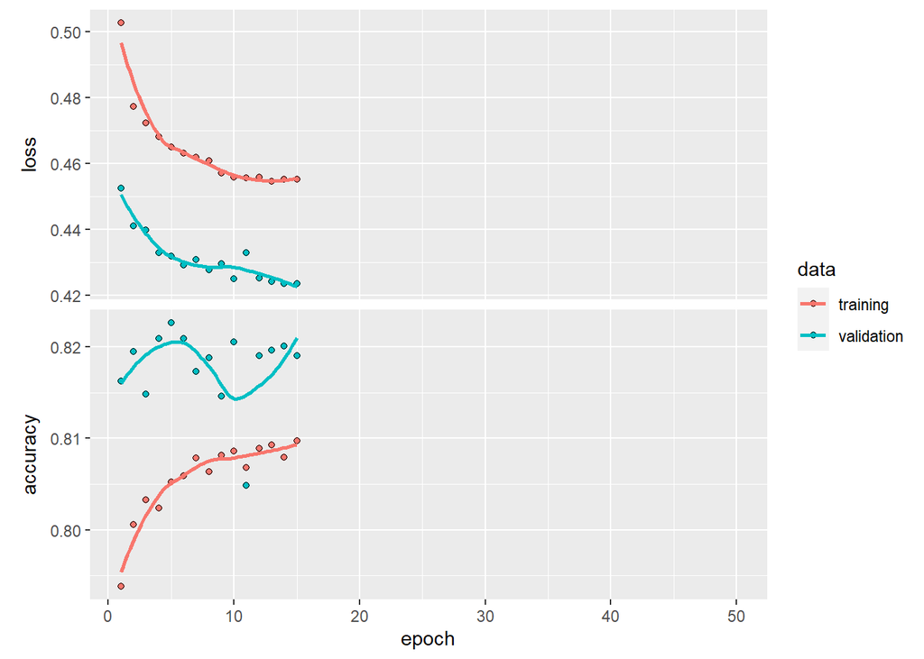

```r
plot(history)
```

### We can try some other techniques in order to see if our neural network gets better results.

The tfruns library will be used to run different experiments.

```r
library(tfruns)

runs1 <- tuning_run("experimento1.R", runs_dir = "runs_exp1",
                   flags = list(dense_units = c(10,25,50,75,100)))
```

```
## 5 total combinations of flags
```

```
## (use sample parameter to run a random subset)
```

```
## Training run 1/5 (flags = list(10))
```

```
## Using run directory runs_exp1/2024-01-14T17-14-30Z
```

```
##
## > FLAGS <- flags(flag_integer("dense_units", 50))
##
## > model <- keras_model_sequential() %>% layer_dropout(0.2,
## +     input_shape = ncol(x_train)) %>% layer_dense(units = FLAGS$dense_units,
## +     activ .... [TRUNCATED]
##
## > optimizador <- "sgd"
##
## > model %>% compile(loss = "binary_crossentropy", optimizer = optimizador,
## +     metric = c("accuracy"))
##
## > history <- model %>% fit(x_train, y_train, epochs = 50,
## +     batch_size = 16, validation_split = 0.2, callbacks = callback_early_stopping(patience .... [TRUNCATED]
## 1186/1186 - 2s - loss: 0.5242 - accuracy: 0.7728 - val_loss: 0.4656 - val_accuracy: 0.8110 - 2s/epoch - 2ms/step
## 1186/1186 - 1s - loss: 0.4849 - accuracy: 0.7966 - val_loss: 0.4489 - val_accuracy: 0.8161 - 1s/epoch - 1ms/step
## 1186/1186 - 1s - loss: 0.4760 - accuracy: 0.7990 - val_loss: 0.4403 - val_accuracy: 0.8201 - 1s/epoch - 1ms/step
## 1186/1186 - 1s - loss: 0.4697 - accuracy: 0.8024 - val_loss: 0.4360 - val_accuracy: 0.8199 - 1s/epoch - 1ms/step
## 1186/1186 - 1s - loss: 0.4688 - accuracy: 0.8026 - val_loss: 0.4326 - val_accuracy: 0.8205 - 1s/epoch - 1ms/step
## 1186/1186 - 1s - loss: 0.4676 - accuracy: 0.8042 - val_loss: 0.4327 - val_accuracy: 0.8194 - 1s/epoch - 1ms/step
## 1186/1186 - 1s - loss: 0.4641 - accuracy: 0.8053 - val_loss: 0.4311 - val_accuracy: 0.8186 - 1s/epoch - 1ms/step
## 1186/1186 - 1s - loss: 0.4614 - accuracy: 0.8054 - val_loss: 0.4303 - val_accuracy: 0.8192 - 1s/epoch - 1ms/step
## 1186/1186 - 1s - loss: 0.4617 - accuracy: 0.8039 - val_loss: 0.4287 - val_accuracy: 0.8205 - 1s/epoch - 1ms/step
## 1186/1186 - 1s - loss: 0.4597 - accuracy: 0.8064 - val_loss: 0.4287 - val_accuracy: 0.8192 - 1s/epoch - 1ms/step
## 1186/1186 - 1s - loss: 0.4594 - accuracy: 0.8077 - val_loss: 0.4278 - val_accuracy: 0.8205 - 1s/epoch - 1ms/step
## 1186/1186 - 1s - loss: 0.4573 - accuracy: 0.8090 - val_loss: 0.4287 - val_accuracy: 0.8192 - 1s/epoch - 1ms/step
## 1186/1186 - 1s - loss: 0.4561 - accuracy: 0.8085 - val_loss: 0.4275 - val_accuracy: 0.8180 - 1s/epoch - 1ms/step
## 1186/1186 - 1s - loss: 0.4549 - accuracy: 0.8094 - val_loss: 0.4262 - val_accuracy: 0.8186 - 1s/epoch - 1ms/step
## 1186/1186 - 1s - loss: 0.4557 - accuracy: 0.8084 - val_loss: 0.4254 - val_accuracy: 0.8201 - 1s/epoch - 1ms/step
```

```
##
## Run completed: runs_exp1/2024-01-14T17-14-30Z
```

```
## Training run 2/5 (flags = list(25))
```

```
## Using run directory runs_exp1/2024-01-14T17-14-51Z
```

```
##
## > FLAGS <- flags(flag_integer("dense_units", 50))
##
## > model <- keras_model_sequential() %>% layer_dropout(0.2,
## +     input_shape = ncol(x_train)) %>% layer_dense(units = FLAGS$dense_units,
## +     activ .... [TRUNCATED]
##
## > optimizador <- "sgd"
##
## > model %>% compile(loss = "binary_crossentropy", optimizer = optimizador,
## +     metric = c("accuracy"))
##
## > history <- model %>% fit(x_train, y_train, epochs = 50,
## +     batch_size = 16, validation_split = 0.2, callbacks = callback_early_stopping(patience .... [TRUNCATED]
## 1186/1186 - 2s - loss: 0.5169 - accuracy: 0.7803 - val_loss: 0.4584 - val_accuracy: 0.8175 - 2s/epoch - 2ms/step
## 1186/1186 - 1s - loss: 0.4841 - accuracy: 0.7981 - val_loss: 0.4468 - val_accuracy: 0.8209 - 1s/epoch - 1ms/step
## 1186/1186 - 1s - loss: 0.4747 - accuracy: 0.8005 - val_loss: 0.4412 - val_accuracy: 0.8199 - 1s/epoch - 1ms/step
## 1186/1186 - 1s - loss: 0.4720 - accuracy: 0.7992 - val_loss: 0.4378 - val_accuracy: 0.8201 - 1s/epoch - 1ms/step
## 1186/1186 - 1s - loss: 0.4685 - accuracy: 0.8023 - val_loss: 0.4398 - val_accuracy: 0.8133 - 1s/epoch - 1ms/step
## 1186/1186 - 1s - loss: 0.4642 - accuracy: 0.8029 - val_loss: 0.4334 - val_accuracy: 0.8216 - 1s/epoch - 1ms/step
## 1186/1186 - 1s - loss: 0.4653 - accuracy: 0.8025 - val_loss: 0.4345 - val_accuracy: 0.8159 - 1s/epoch - 1ms/step
## 1186/1186 - 1s - loss: 0.4614 - accuracy: 0.8056 - val_loss: 0.4320 - val_accuracy: 0.8224 - 1s/epoch - 1ms/step
## 1186/1186 - 1s - loss: 0.4602 - accuracy: 0.8080 - val_loss: 0.4324 - val_accuracy: 0.8165 - 1s/epoch - 1ms/step
## 1186/1186 - 1s - loss: 0.4612 - accuracy: 0.8065 - val_loss: 0.4312 - val_accuracy: 0.8180 - 1s/epoch - 1ms/step
## 1186/1186 - 1s - loss: 0.4599 - accuracy: 0.8088 - val_loss: 0.4317 - val_accuracy: 0.8142 - 1s/epoch - 1ms/step
## 1186/1186 - 1s - loss: 0.4576 - accuracy: 0.8071 - val_loss: 0.4293 - val_accuracy: 0.8203 - 1s/epoch - 1ms/step
## 1186/1186 - 1s - loss: 0.4571 - accuracy: 0.8080 - val_loss: 0.4319 - val_accuracy: 0.8138 - 1s/epoch - 1ms/step
## 1186/1186 - 1s - loss: 0.4558 - accuracy: 0.8076 - val_loss: 0.4271 - val_accuracy: 0.8188 - 1s/epoch - 1ms/step
## 1186/1186 - 1s - loss: 0.4577 - accuracy: 0.8080 - val_loss: 0.4274 - val_accuracy: 0.8190 - 1s/epoch - 1ms/step
## 1186/1186 - 2s - loss: 0.4546 - accuracy: 0.8097 - val_loss: 0.4320 - val_accuracy: 0.8116 - 2s/epoch - 1ms/step
## 1186/1186 - 1s - loss: 0.4574 - accuracy: 0.8094 - val_loss: 0.4273 - val_accuracy: 0.8237 - 1s/epoch - 1ms/step
## 1186/1186 - 1s - loss: 0.4533 - accuracy: 0.8110 - val_loss: 0.4257 - val_accuracy: 0.8182 - 1s/epoch - 1ms/step
## 1186/1186 - 1s - loss: 0.4532 - accuracy: 0.8103 - val_loss: 0.4275 - val_accuracy: 0.8148 - 1s/epoch - 1ms/step
## 1186/1186 - 1s - loss: 0.4528 - accuracy: 0.8111 - val_loss: 0.4249 - val_accuracy: 0.8197 - 1s/epoch - 1ms/step
## 1186/1186 - 1s - loss: 0.4546 - accuracy: 0.8088 - val_loss: 0.4280 - val_accuracy: 0.8138 - 1s/epoch - 1ms/step
## 1186/1186 - 1s - loss: 0.4533 - accuracy: 0.8082 - val_loss: 0.4276 - val_accuracy: 0.8146 - 1s/epoch - 1ms/step
## 1186/1186 - 1s - loss: 0.4531 - accuracy: 0.8104 - val_loss: 0.4238 - val_accuracy: 0.8201 - 1s/epoch - 1ms/step
## 1186/1186 - 1s - loss: 0.4503 - accuracy: 0.8128 - val_loss: 0.4231 - val_accuracy: 0.8201 - 1s/epoch - 1ms/step
## 1186/1186 - 1s - loss: 0.4531 - accuracy: 0.8094 - val_loss: 0.4230 - val_accuracy: 0.8203 - 1s/epoch - 1ms/step
## 1186/1186 - 1s - loss: 0.4511 - accuracy: 0.8117 - val_loss: 0.4243 - val_accuracy: 0.8175 - 1s/epoch - 1ms/step
## 1186/1186 - 1s - loss: 0.4526 - accuracy: 0.8109 - val_loss: 0.4245 - val_accuracy: 0.8165 - 1s/epoch - 1ms/step
```

```
##
## Run completed: runs_exp1/2024-01-14T17-14-51Z
```

```
## Training run 3/5 (flags = list(50))
```

```
## Using run directory runs_exp1/2024-01-14T17-15-29Z
```

```
##
## > FLAGS <- flags(flag_integer("dense_units", 50))
##
## > model <- keras_model_sequential() %>% layer_dropout(0.2,
## +     input_shape = ncol(x_train)) %>% layer_dense(units = FLAGS$dense_units,
## +     activ .... [TRUNCATED]
##
## > optimizador <- "sgd"
##
## > model %>% compile(loss = "binary_crossentropy", optimizer = optimizador,
## +     metric = c("accuracy"))
##
## > history <- model %>% fit(x_train, y_train, epochs = 50,
## +     batch_size = 16, validation_split = 0.2, callbacks = callback_early_stopping(patience .... [TRUNCATED]
## 1186/1186 - 2s - loss: 0.5038 - accuracy: 0.7859 - val_loss: 0.4500 - val_accuracy: 0.8205 - 2s/epoch - 1ms/step
## 1186/1186 - 1s - loss: 0.4758 - accuracy: 0.8024 - val_loss: 0.4391 - val_accuracy: 0.8218 - 1s/epoch - 1ms/step
## 1186/1186 - 1s - loss: 0.4716 - accuracy: 0.8016 - val_loss: 0.4363 - val_accuracy: 0.8186 - 1s/epoch - 1ms/step
## 1186/1186 - 1s - loss: 0.4685 - accuracy: 0.8024 - val_loss: 0.4349 - val_accuracy: 0.8167 - 1s/epoch - 1ms/step
## 1186/1186 - 1s - loss: 0.4642 - accuracy: 0.8051 - val_loss: 0.4311 - val_accuracy: 0.8161 - 1s/epoch - 1ms/step
## 1186/1186 - 1s - loss: 0.4612 - accuracy: 0.8048 - val_loss: 0.4282 - val_accuracy: 0.8222 - 1s/epoch - 1ms/step
## 1186/1186 - 1s - loss: 0.4571 - accuracy: 0.8083 - val_loss: 0.4278 - val_accuracy: 0.8188 - 1s/epoch - 1ms/step
## 1186/1186 - 1s - loss: 0.4598 - accuracy: 0.8055 - val_loss: 0.4273 - val_accuracy: 0.8182 - 1s/epoch - 1ms/step
## 1186/1186 - 1s - loss: 0.4561 - accuracy: 0.8071 - val_loss: 0.4256 - val_accuracy: 0.8249 - 1s/epoch - 1ms/step
## 1186/1186 - 1s - loss: 0.4574 - accuracy: 0.8076 - val_loss: 0.4256 - val_accuracy: 0.8184 - 1s/epoch - 1ms/step
## 1186/1186 - 1s - loss: 0.4550 - accuracy: 0.8086 - val_loss: 0.4250 - val_accuracy: 0.8184 - 1s/epoch - 1ms/step
## 1186/1186 - 1s - loss: 0.4561 - accuracy: 0.8084 - val_loss: 0.4246 - val_accuracy: 0.8224 - 1s/epoch - 1ms/step
## 1186/1186 - 1s - loss: 0.4531 - accuracy: 0.8094 - val_loss: 0.4233 - val_accuracy: 0.8192 - 1s/epoch - 1ms/step
## 1186/1186 - 1s - loss: 0.4521 - accuracy: 0.8110 - val_loss: 0.4225 - val_accuracy: 0.8222 - 1s/epoch - 1ms/step
## 1186/1186 - 1s - loss: 0.4520 - accuracy: 0.8099 - val_loss: 0.4222 - val_accuracy: 0.8230 - 1s/epoch - 1ms/step
## 1186/1186 - 1s - loss: 0.4525 - accuracy: 0.8113 - val_loss: 0.4227 - val_accuracy: 0.8213 - 1s/epoch - 1ms/step
## 1186/1186 - 1s - loss: 0.4509 - accuracy: 0.8115 - val_loss: 0.4217 - val_accuracy: 0.8190 - 1s/epoch - 1ms/step
## 1186/1186 - 1s - loss: 0.4518 - accuracy: 0.8116 - val_loss: 0.4222 - val_accuracy: 0.8171 - 1s/epoch - 1ms/step
## 1186/1186 - 2s - loss: 0.4524 - accuracy: 0.8099 - val_loss: 0.4228 - val_accuracy: 0.8175 - 2s/epoch - 1ms/step
```

```
##
## Run completed: runs_exp1/2024-01-14T17-15-29Z
```

```
## Training run 4/5 (flags = list(75))
```

```
## Using run directory runs_exp1/2024-01-14T17-15-56Z
```

```
##
## > FLAGS <- flags(flag_integer("dense_units", 50))
##
## > model <- keras_model_sequential() %>% layer_dropout(0.2,
## +     input_shape = ncol(x_train)) %>% layer_dense(units = FLAGS$dense_units,
## +     activ .... [TRUNCATED]
##
## > optimizador <- "sgd"
##
## > model %>% compile(loss = "binary_crossentropy", optimizer = optimizador,
## +     metric = c("accuracy"))
##
## > history <- model %>% fit(x_train, y_train, epochs = 50,
## +     batch_size = 16, validation_split = 0.2, callbacks = callback_early_stopping(patience .... [TRUNCATED]
## 1186/1186 - 2s - loss: 0.5123 - accuracy: 0.7845 - val_loss: 0.4524 - val_accuracy: 0.8133 - 2s/epoch - 2ms/step
## 1186/1186 - 1s - loss: 0.4751 - accuracy: 0.8029 - val_loss: 0.4372 - val_accuracy: 0.8207 - 1s/epoch - 1ms/step
## 1186/1186 - 1s - loss: 0.4692 - accuracy: 0.8020 - val_loss: 0.4335 - val_accuracy: 0.8171 - 1s/epoch - 1ms/step
## 1186/1186 - 1s - loss: 0.4628 - accuracy: 0.8054 - val_loss: 0.4300 - val_accuracy: 0.8235 - 1s/epoch - 1ms/step
## 1186/1186 - 1s - loss: 0.4628 - accuracy: 0.8040 - val_loss: 0.4312 - val_accuracy: 0.8152 - 1s/epoch - 1ms/step
## 1186/1186 - 1s - loss: 0.4612 - accuracy: 0.8062 - val_loss: 0.4266 - val_accuracy: 0.8216 - 1s/epoch - 1ms/step
## 1186/1186 - 1s - loss: 0.4588 - accuracy: 0.8064 - val_loss: 0.4260 - val_accuracy: 0.8220 - 1s/epoch - 1ms/step
## 1186/1186 - 1s - loss: 0.4589 - accuracy: 0.8070 - val_loss: 0.4258 - val_accuracy: 0.8203 - 1s/epoch - 1ms/step
## 1186/1186 - 1s - loss: 0.4553 - accuracy: 0.8071 - val_loss: 0.4237 - val_accuracy: 0.8213 - 1s/epoch - 1ms/step
## 1186/1186 - 1s - loss: 0.4523 - accuracy: 0.8099 - val_loss: 0.4232 - val_accuracy: 0.8203 - 1s/epoch - 1ms/step
## 1186/1186 - 1s - loss: 0.4534 - accuracy: 0.8091 - val_loss: 0.4217 - val_accuracy: 0.8213 - 1s/epoch - 1ms/step
## 1186/1186 - 1s - loss: 0.4522 - accuracy: 0.8084 - val_loss: 0.4224 - val_accuracy: 0.8192 - 1s/epoch - 1ms/step
## 1186/1186 - 1s - loss: 0.4515 - accuracy: 0.8110 - val_loss: 0.4252 - val_accuracy: 0.8157 - 1s/epoch - 1ms/step
## 1186/1186 - 1s - loss: 0.4514 - accuracy: 0.8120 - val_loss: 0.4196 - val_accuracy: 0.8230 - 1s/epoch - 1ms/step
```

```
##
## Run completed: runs_exp1/2024-01-14T17-15-56Z
```

```
## Training run 5/5 (flags = list(100))
```

```
## Using run directory runs_exp1/2024-01-14T17-16-15Z
```

```
##
## > FLAGS <- flags(flag_integer("dense_units", 50))
##
## > model <- keras_model_sequential() %>% layer_dropout(0.2,
## +     input_shape = ncol(x_train)) %>% layer_dense(units = FLAGS$dense_units,
## +     activ .... [TRUNCATED]
##
## > optimizador <- "sgd"
##
## > model %>% compile(loss = "binary_crossentropy", optimizer = optimizador,
## +     metric = c("accuracy"))
##
## > history <- model %>% fit(x_train, y_train, epochs = 50,
## +     batch_size = 16, validation_split = 0.2, callbacks = callback_early_stopping(patience .... [TRUNCATED]
## 1186/1186 - 2s - loss: 0.5009 - accuracy: 0.7945 - val_loss: 0.4475 - val_accuracy: 0.8186 - 2s/epoch - 1ms/step
## 1186/1186 - 1s - loss: 0.4744 - accuracy: 0.8032 - val_loss: 0.4372 - val_accuracy: 0.8161 - 1s/epoch - 1ms/step
## 1186/1186 - 1s - loss: 0.4673 - accuracy: 0.8028 - val_loss: 0.4318 - val_accuracy: 0.8220 - 1s/epoch - 1ms/step
## 1186/1186 - 1s - loss: 0.4656 - accuracy: 0.8043 - val_loss: 0.4309 - val_accuracy: 0.8188 - 1s/epoch - 1ms/step
## 1186/1186 - 1s - loss: 0.4636 - accuracy: 0.8058 - val_loss: 0.4267 - val_accuracy: 0.8243 - 1s/epoch - 1ms/step
## 1186/1186 - 1s - loss: 0.4589 - accuracy: 0.8082 - val_loss: 0.4260 - val_accuracy: 0.8203 - 1s/epoch - 1ms/step
## 1186/1186 - 1s - loss: 0.4543 - accuracy: 0.8093 - val_loss: 0.4243 - val_accuracy: 0.8249 - 1s/epoch - 1ms/step
## 1186/1186 - 1s - loss: 0.4585 - accuracy: 0.8057 - val_loss: 0.4257 - val_accuracy: 0.8245 - 1s/epoch - 1ms/step
## 1186/1186 - 1s - loss: 0.4548 - accuracy: 0.8074 - val_loss: 0.4248 - val_accuracy: 0.8188 - 1s/epoch - 1ms/step
## 1186/1186 - 1s - loss: 0.4522 - accuracy: 0.8108 - val_loss: 0.4232 - val_accuracy: 0.8220 - 1s/epoch - 1ms/step
## 1186/1186 - 1s - loss: 0.4545 - accuracy: 0.8096 - val_loss: 0.4228 - val_accuracy: 0.8228 - 1s/epoch - 1ms/step
## 1186/1186 - 1s - loss: 0.4534 - accuracy: 0.8098 - val_loss: 0.4230 - val_accuracy: 0.8203 - 1s/epoch - 1ms/step
## 1186/1186 - 1s - loss: 0.4533 - accuracy: 0.8085 - val_loss: 0.4198 - val_accuracy: 0.8249 - 1s/epoch - 1ms/step
## 1186/1186 - 1s - loss: 0.4517 - accuracy: 0.8095 - val_loss: 0.4204 - val_accuracy: 0.8245 - 1s/epoch - 1ms/step
## 1186/1186 - 1s - loss: 0.4510 - accuracy: 0.8122 - val_loss: 0.4204 - val_accuracy: 0.8237 - 1s/epoch - 1ms/step
## 1186/1186 - 1s - loss: 0.4521 - accuracy: 0.8123 - val_loss: 0.4237 - val_accuracy: 0.8157 - 1s/epoch - 1ms/step
## 1186/1186 - 1s - loss: 0.4493 - accuracy: 0.8112 - val_loss: 0.4250 - val_accuracy: 0.8152 - 1s/epoch - 1ms/step
```

```
##
## Run completed: runs_exp1/2024-01-14T17-16-15Z
```

We will now observe the results variations for different scenarios in the first activation layer of our neural network, where the values of 10, 25, 50, 75 and 100 neurons will be compared.

```r
library(dplyr)

best_results <- runs1 %>%
  select(flag_dense_units,metric_accuracy,metric_val_accuracy,epochs_completed) %>%
  arrange(desc(metric_val_accuracy))
best_results
```

```
## Data frame: 5 x 4
##   flag_dense_units metric_accuracy metric_val_accuracy epochs_completed
## 1               75          0.8120              0.8230               14
## 2               10          0.8084              0.8201               15
## 3               50          0.8099              0.8175               19
## 4               25          0.8109              0.8165               27
## 5              100          0.8112              0.8152               17
```

```r
model <- create_model(x_train, 10)
summary(model)
```

```
## Model: "sequential"
## ________________________________________________________________________________
##  Layer (type)                       Output Shape                    Param #
## ================================================================================
##  dropout (Dropout)                  (None, 29)                      0
##  dense_1 (Dense)                    (None, 10)                      300
##  dense (Dense)                      (None, 1)                       11
## ================================================================================
## Total params: 311 (1.21 KB)
## Trainable params: 311 (1.21 KB)
## Non-trainable params: 0 (0.00 Byte)
## ________________________________________________________________________________
```

```r
history <- model %>% fit(x_train, y_train,
                          epochs = 50,
                          batch_size = 16,
                          validation_split = .2,
                          callbacks = callback_early_stopping(patience = 10,
                                                               monitor = 'val_accuracy',
                                                               restore_best_weights = TRUE))
```

```
## 1186/1186 - 1s - loss: 0.5174 - accuracy: 0.7904 - val_loss: 0.4640 - val_accuracy: 0.8186 - 1s/epoch - 1ms/step
## 1186/1186 - 1s - loss: 0.4885 - accuracy: 0.7980 - val_loss: 0.4534 - val_accuracy: 0.8205 - 1s/epoch - 889us/step
## 1186/1186 - 1s - loss: 0.4801 - accuracy: 0.8005 - val_loss: 0.4465 - val_accuracy: 0.8239 - 1s/epoch - 913us/step
## 1186/1186 - 1s - loss: 0.4750 - accuracy: 0.8025 - val_loss: 0.4435 - val_accuracy: 0.8232 - 1s/epoch - 900us/step
## 1186/1186 - 1s - loss: 0.4722 - accuracy: 0.8025 - val_loss: 0.4417 - val_accuracy: 0.8213 - 1s/epoch - 913us/step
## 1186/1186 - 1s - loss: 0.4697 - accuracy: 0.8044 - val_loss: 0.4398 - val_accuracy: 0.8235 - 1s/epoch - 897us/step
## 1186/1186 - 1s - loss: 0.4693 - accuracy: 0.8032 - val_loss: 0.4366 - val_accuracy: 0.8228 - 1s/epoch - 879us/step
## 1186/1186 - 1s - loss: 0.4676 - accuracy: 0.8049 - val_loss: 0.4372 - val_accuracy: 0.8209 - 1s/epoch - 851us/step
## 1186/1186 - 1s - loss: 0.4669 - accuracy: 0.8039 - val_loss: 0.4353 - val_accuracy: 0.8226 - 987ms/epoch - 833us/step
## 1186/1186 - 1s - loss: 0.4666 - accuracy: 0.8052 - val_loss: 0.4359 - val_accuracy: 0.8199 - 1s/epoch - 848us/step
## 1186/1186 - 1s - loss: 0.4676 - accuracy: 0.8027 - val_loss: 0.4336 - val_accuracy: 0.8235 - 1s/epoch - 844us/step
## 1186/1186 - 1s - loss: 0.4640 - accuracy: 0.8045 - val_loss: 0.4326 - val_accuracy: 0.8237 - 1000ms/epoch - 843us/step
## 1186/1186 - 1s - loss: 0.4625 - accuracy: 0.8063 - val_loss: 0.4321 - val_accuracy: 0.8247 - 1s/epoch - 887us/step
## 1186/1186 - 1s - loss: 0.4624 - accuracy: 0.8049 - val_loss: 0.4313 - val_accuracy: 0.8254 - 1s/epoch - 886us/step
## 1186/1186 - 1s - loss: 0.4647 - accuracy: 0.8056 - val_loss: 0.4326 - val_accuracy: 0.8197 - 1s/epoch - 914us/step
## 1186/1186 - 1s - loss: 0.4649 - accuracy: 0.8040 - val_loss: 0.4334 - val_accuracy: 0.8161 - 1s/epoch - 922us/step
## 1186/1186 - 1s - loss: 0.4604 - accuracy: 0.8079 - val_loss: 0.4310 - val_accuracy: 0.8232 - 1s/epoch - 891us/step
## 1186/1186 - 1s - loss: 0.4615 - accuracy: 0.8052 - val_loss: 0.4293 - val_accuracy: 0.8251 - 1s/epoch - 852us/step
## 1186/1186 - 1s - loss: 0.4612 - accuracy: 0.8056 - val_loss: 0.4306 - val_accuracy: 0.8262 - 1s/epoch - 853us/step
## 1186/1186 - 1s - loss: 0.4594 - accuracy: 0.8082 - val_loss: 0.4286 - val_accuracy: 0.8222 - 990ms/epoch - 835us/step
## 1186/1186 - 1s - loss: 0.4603 - accuracy: 0.8058 - val_loss: 0.4290 - val_accuracy: 0.8247 - 1s/epoch - 849us/step
## 1186/1186 - 1s - loss: 0.4595 - accuracy: 0.8067 - val_loss: 0.4276 - val_accuracy: 0.8260 - 1s/epoch - 855us/step
## 1186/1186 - 1s - loss: 0.4582 - accuracy: 0.8073 - val_loss: 0.4271 - val_accuracy: 0.8235 - 1s/epoch - 894us/step
## 1186/1186 - 1s - loss: 0.4595 - accuracy: 0.8053 - val_loss: 0.4268 - val_accuracy: 0.8258 - 1s/epoch - 894us/step
## 1186/1186 - 1s - loss: 0.4593 - accuracy: 0.8087 - val_loss: 0.4291 - val_accuracy: 0.8169 - 1s/epoch - 890us/step
## 1186/1186 - 1s - loss: 0.4591 - accuracy: 0.8076 - val_loss: 0.4263 - val_accuracy: 0.8243 - 1s/epoch - 899us/step
## 1186/1186 - 1s - loss: 0.4598 - accuracy: 0.8065 - val_loss: 0.4276 - val_accuracy: 0.8194 - 1s/epoch - 873us/step
## 1186/1186 - 1s - loss: 0.4595 - accuracy: 0.8076 - val_loss: 0.4262 - val_accuracy: 0.8237 - 993ms/epoch - 837us/step
## 1186/1186 - 1s - loss: 0.4588 - accuracy: 0.8066 - val_loss: 0.4252 - val_accuracy: 0.8254 - 1s/epoch - 867us/step
```

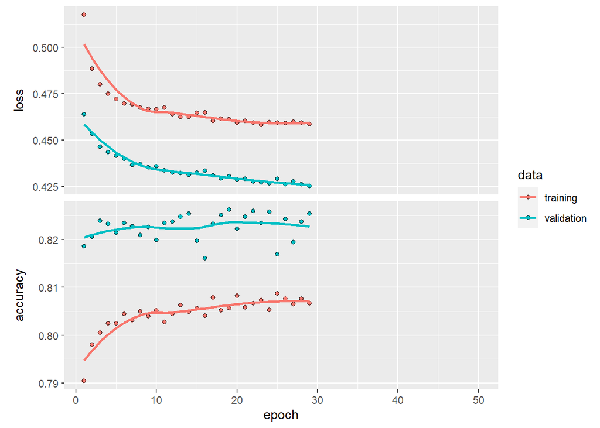

```r
plot(history)
```

```r
history
```

```
##
## Final epoch (plot to see history):
##         loss: 0.4588
##     accuracy: 0.8066
##     val_loss: 0.4252
## val_accuracy: 0.8254
```

```r
metrics <- model %>% evaluate(x_test, y_test)
```

```
## 185/185 - 0s - loss: 0.4586 - accuracy: 0.8065 - 94ms/epoch - 508us/step
```

### We can also try different optimizers and do some new experiments in order to get better results.

```r
runs2 <- tuning_run("experimento2.R", runs_dir = "runs_exp2",
                   flags = list(dense_units = c(10, 50),
                                optimizers = c("sgd", "adam", "rmsprop"),
                                epochs = c(50),
                                batch_size = c(16)))
```

```
## 6 total combinations of flags
```

```
## (use sample parameter to run a random subset)
```

```
## Training run 1/6 (flags = list(10, "sgd", 50, 16))
```

```
## Using run directory runs_exp2/2024-01-14T17-17-08Z
```

```
##
## > FLAGS <- flags(flag_integer("dense_units", 50), flag_integer("epochs",
## +     50), flag_string("optimizers", "sgd"), flag_integer("batch_size",
## +   .... [TRUNCATED]
##
## > model <- keras_model_sequential() %>% layer_dropout(0.2,
## +     input_shape = ncol(x_train)) %>% layer_dense(units = FLAGS$dense_units,
## +     activ .... [TRUNCATED]
##
## > model %>% compile(loss = "binary_crossentropy", optimizer = FLAGS$optimizers,
## +     metric = c("accuracy"))
##
## > history <- model %>% fit(x_train, y_train, epochs = FLAGS$epochs,
## +     batch_size = FLAGS$batch_size, validation_split = 0.2)
## 1186/1186 - 2s - loss: 0.5420 - accuracy: 0.7619 - val_loss: 0.4667 - val_accuracy: 0.8159 - 2s/epoch - 1ms/step
## 1186/1186 - 1s - loss: 0.4832 - accuracy: 0.8005 - val_loss: 0.4490 - val_accuracy: 0.8125 - 1s/epoch - 1ms/step
## 1186/1186 - 1s - loss: 0.4706 - accuracy: 0.8032 - val_loss: 0.4387 - val_accuracy: 0.8180 - 1s/epoch - 1ms/step
## 1186/1186 - 1s - loss: 0.4693 - accuracy: 0.8029 - val_loss: 0.4350 - val_accuracy: 0.8180 - 1s/epoch - 1ms/step
## 1186/1186 - 1s - loss: 0.4641 - accuracy: 0.8049 - val_loss: 0.4332 - val_accuracy: 0.8182 - 1s/epoch - 1ms/step
## 1186/1186 - 1s - loss: 0.4649 - accuracy: 0.8052 - val_loss: 0.4315 - val_accuracy: 0.8192 - 1s/epoch - 1ms/step
## 1186/1186 - 1s - loss: 0.4628 - accuracy: 0.8061 - val_loss: 0.4330 - val_accuracy: 0.8146 - 1s/epoch - 1ms/step
## 1186/1186 - 1s - loss: 0.4611 - accuracy: 0.8076 - val_loss: 0.4297 - val_accuracy: 0.8184 - 1s/epoch - 1ms/step
## 1186/1186 - 1s - loss: 0.4603 - accuracy: 0.8072 - val_loss: 0.4285 - val_accuracy: 0.8190 - 1s/epoch - 1ms/step
## 1186/1186 - 1s - loss: 0.4583 - accuracy: 0.8104 - val_loss: 0.4292 - val_accuracy: 0.8163 - 1s/epoch - 1ms/step
## 1186/1186 - 1s - loss: 0.4567 - accuracy: 0.8095 - val_loss: 0.4293 - val_accuracy: 0.8182 - 1s/epoch - 1ms/step
## 1186/1186 - 1s - loss: 0.4598 - accuracy: 0.8063 - val_loss: 0.4274 - val_accuracy: 0.8182 - 1s/epoch - 1ms/step
## 1186/1186 - 1s - loss: 0.4583 - accuracy: 0.8084 - val_loss: 0.4296 - val_accuracy: 0.8161 - 1s/epoch - 1ms/step
## 1186/1186 - 1s - loss: 0.4569 - accuracy: 0.8073 - val_loss: 0.4263 - val_accuracy: 0.8199 - 1s/epoch - 1ms/step
## 1186/1186 - 1s - loss: 0.4567 - accuracy: 0.8089 - val_loss: 0.4282 - val_accuracy: 0.8152 - 1s/epoch - 1ms/step
## 1186/1186 - 1s - loss: 0.4560 - accuracy: 0.8084 - val_loss: 0.4282 - val_accuracy: 0.8194 - 1s/epoch - 1ms/step
## 1186/1186 - 1s - loss: 0.4545 - accuracy: 0.8094 - val_loss: 0.4258 - val_accuracy: 0.8207 - 1s/epoch - 1ms/step
## 1186/1186 - 1s - loss: 0.4558 - accuracy: 0.8099 - val_loss: 0.4254 - val_accuracy: 0.8194 - 1s/epoch - 1ms/step
## 1186/1186 - 1s - loss: 0.4554 - accuracy: 0.8107 - val_loss: 0.4265 - val_accuracy: 0.8173 - 1s/epoch - 1ms/step
## 1186/1186 - 1s - loss: 0.4556 - accuracy: 0.8083 - val_loss: 0.4250 - val_accuracy: 0.8201 - 1s/epoch - 1ms/step
## 1186/1186 - 1s - loss: 0.4538 - accuracy: 0.8112 - val_loss: 0.4240 - val_accuracy: 0.8216 - 1s/epoch - 1ms/step
## 1186/1186 - 1s - loss: 0.4561 - accuracy: 0.8094 - val_loss: 0.4251 - val_accuracy: 0.8194 - 1s/epoch - 1ms/step
## 1186/1186 - 1s - loss: 0.4538 - accuracy: 0.8112 - val_loss: 0.4266 - val_accuracy: 0.8165 - 1s/epoch - 1ms/step
## 1186/1186 - 1s - loss: 0.4535 - accuracy: 0.8092 - val_loss: 0.4255 - val_accuracy: 0.8182 - 1s/epoch - 1ms/step
## 1186/1186 - 1s - loss: 0.4545 - accuracy: 0.8080 - val_loss: 0.4246 - val_accuracy: 0.8192 - 1s/epoch - 1ms/step
## 1186/1186 - 1s - loss: 0.4532 - accuracy: 0.8083 - val_loss: 0.4246 - val_accuracy: 0.8203 - 1s/epoch - 1ms/step
```

[output cut: 9 more lines]

```
## 1186/1186 - 1s - loss: 0.4531 - accuracy: 0.8106 - val_loss: 0.4245 - val_accuracy: 0.8190 - 1s/epoch - 1ms/step
## 1186/1186 - 1s - loss: 0.4516 - accuracy: 0.8113 - val_loss: 0.4238 - val_accuracy: 0.8188 - 1s/epoch - 1ms/step
## 1186/1186 - 1s - loss: 0.4506 - accuracy: 0.8116 - val_loss: 0.4232 - val_accuracy: 0.8201 - 1s/epoch - 1ms/step
## 1186/1186 - 1s - loss: 0.4512 - accuracy: 0.8111 - val_loss: 0.4236 - val_accuracy: 0.8186 - 1s/epoch - 1ms/step
## 1186/1186 - 1s - loss: 0.4520 - accuracy: 0.8092 - val_loss: 0.4243 - val_accuracy: 0.8192 - 1s/epoch - 1ms/step
## 1186/1186 - 1s - loss: 0.4538 - accuracy: 0.8106 - val_loss: 0.4244 - val_accuracy: 0.8192 - 1s/epoch - 1ms/step
## 1186/1186 - 1s - loss: 0.4502 - accuracy: 0.8106 - val_loss: 0.4233 - val_accuracy: 0.8186 - 1s/epoch - 1ms/step
## 1186/1186 - 1s - loss: 0.4497 - accuracy: 0.8120 - val_loss: 0.4209 - val_accuracy: 0.8245 - 1s/epoch - 1ms/step
## 1186/1186 - 1s - loss: 0.4518 - accuracy: 0.8112 - val_loss: 0.4223 - val_accuracy: 0.8213 - 1s/epoch - 1ms/step
## 1186/1186 - 1s - loss: 0.4521 - accuracy: 0.8104 - val_loss: 0.4220 - val_accuracy: 0.8207 - 1s/epoch - 1ms/step
## 1186/1186 - 1s - loss: 0.4502 - accuracy: 0.8122 - val_loss: 0.4214 - val_accuracy: 0.8230 - 1s/epoch - 1ms/step
## 1186/1186 - 1s - loss: 0.4505 - accuracy: 0.8118 - val_loss: 0.4210 - val_accuracy: 0.8226 - 1s/epoch - 1ms/step
## 1186/1186 - 1s - loss: 0.4520 - accuracy: 0.8108 - val_loss: 0.4226 - val_accuracy: 0.8209 - 1s/epoch - 1ms/step
## 1186/1186 - 1s - loss: 0.4511 - accuracy: 0.8104 - val_loss: 0.4227 - val_accuracy: 0.8197 - 1s/epoch - 1ms/step
## 1186/1186 - 1s - loss: 0.4496 - accuracy: 0.8143 - val_loss: 0.4234 - val_accuracy: 0.8190 - 1s/epoch - 1ms/step
```

```
##
## Run completed: runs_exp2/2024-01-14T17-17-08Z
```

```
## Training run 2/6 (flags = list(50, "sgd", 50, 16))
```

```
## Using run directory runs_exp2/2024-01-14T17-18-16Z
```

```
##
## > FLAGS <- flags(flag_integer("dense_units", 50), flag_integer("epochs",
## +     50), flag_string("optimizers", "sgd"), flag_integer("batch_size",
## +   .... [TRUNCATED]
##
## > model <- keras_model_sequential() %>% layer_dropout(0.2,
## +     input_shape = ncol(x_train)) %>% layer_dense(units = FLAGS$dense_units,
## +     activ .... [TRUNCATED]
##
## > model %>% compile(loss = "binary_crossentropy", optimizer = FLAGS$optimizers,
## +     metric = c("accuracy"))
##
## > history <- model %>% fit(x_train, y_train, epochs = FLAGS$epochs,
## +     batch_size = FLAGS$batch_size, validation_split = 0.2)
## 1186/1186 - 2s - loss: 0.5032 - accuracy: 0.7914 - val_loss: 0.4518 - val_accuracy: 0.8201 - 2s/epoch - 1ms/step
## 1186/1186 - 1s - loss: 0.4775 - accuracy: 0.8011 - val_loss: 0.4400 - val_accuracy: 0.8222 - 1s/epoch - 1ms/step
## 1186/1186 - 1s - loss: 0.4749 - accuracy: 0.8027 - val_loss: 0.4373 - val_accuracy: 0.8241 - 1s/epoch - 1ms/step
## 1186/1186 - 1s - loss: 0.4648 - accuracy: 0.8054 - val_loss: 0.4317 - val_accuracy: 0.8188 - 1s/epoch - 1ms/step
## 1186/1186 - 1s - loss: 0.4648 - accuracy: 0.8035 - val_loss: 0.4308 - val_accuracy: 0.8188 - 1s/epoch - 1ms/step
## 1186/1186 - 1s - loss: 0.4625 - accuracy: 0.8053 - val_loss: 0.4273 - val_accuracy: 0.8186 - 1s/epoch - 1ms/step
## 1186/1186 - 1s - loss: 0.4632 - accuracy: 0.8044 - val_loss: 0.4277 - val_accuracy: 0.8167 - 1s/epoch - 1ms/step
## 1186/1186 - 1s - loss: 0.4597 - accuracy: 0.8048 - val_loss: 0.4245 - val_accuracy: 0.8224 - 1s/epoch - 1ms/step
## 1186/1186 - 1s - loss: 0.4554 - accuracy: 0.8087 - val_loss: 0.4242 - val_accuracy: 0.8182 - 1s/epoch - 1ms/step
## 1186/1186 - 1s - loss: 0.4556 - accuracy: 0.8092 - val_loss: 0.4248 - val_accuracy: 0.8171 - 1s/epoch - 1ms/step
## 1186/1186 - 1s - loss: 0.4535 - accuracy: 0.8081 - val_loss: 0.4216 - val_accuracy: 0.8207 - 1s/epoch - 1ms/step
## 1186/1186 - 1s - loss: 0.4546 - accuracy: 0.8078 - val_loss: 0.4213 - val_accuracy: 0.8243 - 1s/epoch - 1ms/step
## 1186/1186 - 1s - loss: 0.4526 - accuracy: 0.8101 - val_loss: 0.4218 - val_accuracy: 0.8188 - 1s/epoch - 1ms/step
## 1186/1186 - 1s - loss: 0.4516 - accuracy: 0.8115 - val_loss: 0.4222 - val_accuracy: 0.8182 - 1s/epoch - 1ms/step
## 1186/1186 - 1s - loss: 0.4509 - accuracy: 0.8092 - val_loss: 0.4215 - val_accuracy: 0.8188 - 1s/epoch - 1ms/step
## 1186/1186 - 1s - loss: 0.4539 - accuracy: 0.8087 - val_loss: 0.4209 - val_accuracy: 0.8197 - 1s/epoch - 1ms/step
## 1186/1186 - 1s - loss: 0.4504 - accuracy: 0.8105 - val_loss: 0.4210 - val_accuracy: 0.8184 - 1s/epoch - 1ms/step
## 1186/1186 - 1s - loss: 0.4500 - accuracy: 0.8107 - val_loss: 0.4218 - val_accuracy: 0.8182 - 1s/epoch - 1ms/step
## 1186/1186 - 1s - loss: 0.4505 - accuracy: 0.8096 - val_loss: 0.4209 - val_accuracy: 0.8186 - 1s/epoch - 1ms/step
## 1186/1186 - 1s - loss: 0.4504 - accuracy: 0.8114 - val_loss: 0.4194 - val_accuracy: 0.8192 - 1s/epoch - 1ms/step
## 1186/1186 - 1s - loss: 0.4493 - accuracy: 0.8094 - val_loss: 0.4202 - val_accuracy: 0.8207 - 1s/epoch - 1ms/step
## 1186/1186 - 1s - loss: 0.4490 - accuracy: 0.8101 - val_loss: 0.4200 - val_accuracy: 0.8190 - 1s/epoch - 1ms/step
## 1186/1186 - 1s - loss: 0.4487 - accuracy: 0.8112 - val_loss: 0.4215 - val_accuracy: 0.8184 - 1s/epoch - 1ms/step
## 1186/1186 - 1s - loss: 0.4497 - accuracy: 0.8107 - val_loss: 0.4205 - val_accuracy: 0.8188 - 1s/epoch - 1ms/step
## 1186/1186 - 1s - loss: 0.4486 - accuracy: 0.8104 - val_loss: 0.4199 - val_accuracy: 0.8201 - 1s/epoch - 1ms/step
## 1186/1186 - 1s - loss: 0.4482 - accuracy: 0.8113 - val_loss: 0.4169 - val_accuracy: 0.8273 - 1s/epoch - 1ms/step
```

[output cut: 9 more lines]

```
## 1186/1186 - 1s - loss: 0.4454 - accuracy: 0.8114 - val_loss: 0.4168 - val_accuracy: 0.8230 - 1s/epoch - 1ms/step
## 1186/1186 - 1s - loss: 0.4477 - accuracy: 0.8110 - val_loss: 0.4178 - val_accuracy: 0.8249 - 1s/epoch - 1ms/step
## 1186/1186 - 1s - loss: 0.4460 - accuracy: 0.8114 - val_loss: 0.4163 - val_accuracy: 0.8262 - 1s/epoch - 1ms/step
## 1186/1186 - 1s - loss: 0.4464 - accuracy: 0.8128 - val_loss: 0.4189 - val_accuracy: 0.8241 - 1s/epoch - 1ms/step
## 1186/1186 - 1s - loss: 0.4488 - accuracy: 0.8113 - val_loss: 0.4174 - val_accuracy: 0.8241 - 1s/epoch - 1ms/step
## 1186/1186 - 1s - loss: 0.4448 - accuracy: 0.8113 - val_loss: 0.4185 - val_accuracy: 0.8220 - 1s/epoch - 1ms/step
## 1186/1186 - 1s - loss: 0.4464 - accuracy: 0.8121 - val_loss: 0.4177 - val_accuracy: 0.8209 - 1s/epoch - 1ms/step
## 1186/1186 - 1s - loss: 0.4461 - accuracy: 0.8115 - val_loss: 0.4190 - val_accuracy: 0.8258 - 1s/epoch - 1ms/step
## 1186/1186 - 1s - loss: 0.4456 - accuracy: 0.8117 - val_loss: 0.4141 - val_accuracy: 0.8289 - 1s/epoch - 1ms/step
## 1186/1186 - 2s - loss: 0.4455 - accuracy: 0.8121 - val_loss: 0.4174 - val_accuracy: 0.8239 - 2s/epoch - 1ms/step
## 1186/1186 - 1s - loss: 0.4463 - accuracy: 0.8127 - val_loss: 0.4164 - val_accuracy: 0.8262 - 1s/epoch - 1ms/step
## 1186/1186 - 1s - loss: 0.4432 - accuracy: 0.8129 - val_loss: 0.4146 - val_accuracy: 0.8285 - 1s/epoch - 1ms/step
## 1186/1186 - 1s - loss: 0.4439 - accuracy: 0.8126 - val_loss: 0.4172 - val_accuracy: 0.8209 - 1s/epoch - 1ms/step
## 1186/1186 - 1s - loss: 0.4453 - accuracy: 0.8121 - val_loss: 0.4171 - val_accuracy: 0.8247 - 1s/epoch - 1ms/step
## 1186/1186 - 1s - loss: 0.4452 - accuracy: 0.8127 - val_loss: 0.4175 - val_accuracy: 0.8260 - 1s/epoch - 1ms/step
```

```
##
## Run completed: runs_exp2/2024-01-14T17-18-16Z
```

```
## Training run 3/6 (flags = list(10, "adam", 50, 16))
```

```
## Using run directory runs_exp2/2024-01-14T17-19-24Z
```

```
##
## > FLAGS <- flags(flag_integer("dense_units", 50), flag_integer("epochs",
## +     50), flag_string("optimizers", "sgd"), flag_integer("batch_size",
## +   .... [TRUNCATED]
##
## > model <- keras_model_sequential() %>% layer_dropout(0.2,
## +     input_shape = ncol(x_train)) %>% layer_dense(units = FLAGS$dense_units,
## +     activ .... [TRUNCATED]
##
## > model %>% compile(loss = "binary_crossentropy", optimizer = FLAGS$optimizers,
## +     metric = c("accuracy"))
##
## > history <- model %>% fit(x_train, y_train, epochs = FLAGS$epochs,
## +     batch_size = FLAGS$batch_size, validation_split = 0.2)
## 1186/1186 - 2s - loss: 0.4972 - accuracy: 0.7946 - val_loss: 0.4340 - val_accuracy: 0.8247 - 2s/epoch - 2ms/step
## 1186/1186 - 1s - loss: 0.4681 - accuracy: 0.8030 - val_loss: 0.4309 - val_accuracy: 0.8197 - 1s/epoch - 1ms/step
## 1186/1186 - 1s - loss: 0.4668 - accuracy: 0.8053 - val_loss: 0.4322 - val_accuracy: 0.8173 - 1s/epoch - 1ms/step
## 1186/1186 - 2s - loss: 0.4607 - accuracy: 0.8068 - val_loss: 0.4304 - val_accuracy: 0.8218 - 2s/epoch - 1ms/step
## 1186/1186 - 1s - loss: 0.4618 - accuracy: 0.8027 - val_loss: 0.4272 - val_accuracy: 0.8228 - 1s/epoch - 1ms/step
## 1186/1186 - 1s - loss: 0.4614 - accuracy: 0.8031 - val_loss: 0.4289 - val_accuracy: 0.8175 - 1s/epoch - 1ms/step
## 1186/1186 - 1s - loss: 0.4598 - accuracy: 0.8062 - val_loss: 0.4263 - val_accuracy: 0.8201 - 1s/epoch - 1ms/step
## 1186/1186 - 1s - loss: 0.4557 - accuracy: 0.8072 - val_loss: 0.4257 - val_accuracy: 0.8241 - 1s/epoch - 1ms/step
## 1186/1186 - 1s - loss: 0.4551 - accuracy: 0.8070 - val_loss: 0.4275 - val_accuracy: 0.8186 - 1s/epoch - 1ms/step
## 1186/1186 - 1s - loss: 0.4576 - accuracy: 0.8054 - val_loss: 0.4253 - val_accuracy: 0.8260 - 1s/epoch - 1ms/step
## 1186/1186 - 1s - loss: 0.4573 - accuracy: 0.8055 - val_loss: 0.4270 - val_accuracy: 0.8207 - 1s/epoch - 1ms/step
## 1186/1186 - 1s - loss: 0.4562 - accuracy: 0.8077 - val_loss: 0.4296 - val_accuracy: 0.8163 - 1s/epoch - 1ms/step
## 1186/1186 - 1s - loss: 0.4548 - accuracy: 0.8075 - val_loss: 0.4286 - val_accuracy: 0.8192 - 1s/epoch - 1ms/step
## 1186/1186 - 1s - loss: 0.4539 - accuracy: 0.8067 - val_loss: 0.4246 - val_accuracy: 0.8245 - 1s/epoch - 1ms/step
## 1186/1186 - 1s - loss: 0.4562 - accuracy: 0.8057 - val_loss: 0.4256 - val_accuracy: 0.8199 - 1s/epoch - 1ms/step
## 1186/1186 - 1s - loss: 0.4539 - accuracy: 0.8075 - val_loss: 0.4257 - val_accuracy: 0.8197 - 1s/epoch - 1ms/step
## 1186/1186 - 1s - loss: 0.4540 - accuracy: 0.8062 - val_loss: 0.4233 - val_accuracy: 0.8228 - 1s/epoch - 1ms/step
## 1186/1186 - 1s - loss: 0.4535 - accuracy: 0.8064 - val_loss: 0.4248 - val_accuracy: 0.8224 - 1s/epoch - 1ms/step
## 1186/1186 - 1s - loss: 0.4550 - accuracy: 0.8088 - val_loss: 0.4241 - val_accuracy: 0.8228 - 1s/epoch - 1ms/step
## 1186/1186 - 1s - loss: 0.4532 - accuracy: 0.8094 - val_loss: 0.4251 - val_accuracy: 0.8224 - 1s/epoch - 1ms/step
## 1186/1186 - 2s - loss: 0.4526 - accuracy: 0.8085 - val_loss: 0.4278 - val_accuracy: 0.8165 - 2s/epoch - 1ms/step
## 1186/1186 - 2s - loss: 0.4552 - accuracy: 0.8070 - val_loss: 0.4244 - val_accuracy: 0.8188 - 2s/epoch - 1ms/step
## 1186/1186 - 2s - loss: 0.4532 - accuracy: 0.8064 - val_loss: 0.4278 - val_accuracy: 0.8167 - 2s/epoch - 1ms/step
## 1186/1186 - 1s - loss: 0.4535 - accuracy: 0.8073 - val_loss: 0.4246 - val_accuracy: 0.8194 - 1s/epoch - 1ms/step
## 1186/1186 - 1s - loss: 0.4517 - accuracy: 0.8088 - val_loss: 0.4249 - val_accuracy: 0.8182 - 1s/epoch - 1ms/step
## 1186/1186 - 1s - loss: 0.4540 - accuracy: 0.8056 - val_loss: 0.4237 - val_accuracy: 0.8182 - 1s/epoch - 1ms/step
```

[output cut: 9 more lines]

```
## 1186/1186 - 1s - loss: 0.4504 - accuracy: 0.8083 - val_loss: 0.4221 - val_accuracy: 0.8199 - 1s/epoch - 1ms/step
## 1186/1186 - 1s - loss: 0.4501 - accuracy: 0.8112 - val_loss: 0.4249 - val_accuracy: 0.8190 - 1s/epoch - 1ms/step
## 1186/1186 - 1s - loss: 0.4522 - accuracy: 0.8083 - val_loss: 0.4252 - val_accuracy: 0.8180 - 1s/epoch - 1ms/step
## 1186/1186 - 1s - loss: 0.4517 - accuracy: 0.8085 - val_loss: 0.4241 - val_accuracy: 0.8192 - 1s/epoch - 1ms/step
## 1186/1186 - 1s - loss: 0.4488 - accuracy: 0.8107 - val_loss: 0.4243 - val_accuracy: 0.8192 - 1s/epoch - 1ms/step
## 1186/1186 - 1s - loss: 0.4508 - accuracy: 0.8071 - val_loss: 0.4262 - val_accuracy: 0.8167 - 1s/epoch - 1ms/step
## 1186/1186 - 1s - loss: 0.4523 - accuracy: 0.8075 - val_loss: 0.4253 - val_accuracy: 0.8163 - 1s/epoch - 1ms/step
## 1186/1186 - 1s - loss: 0.4495 - accuracy: 0.8096 - val_loss: 0.4246 - val_accuracy: 0.8209 - 1s/epoch - 1ms/step
## 1186/1186 - 1s - loss: 0.4502 - accuracy: 0.8090 - val_loss: 0.4238 - val_accuracy: 0.8203 - 1s/epoch - 1ms/step
## 1186/1186 - 1s - loss: 0.4493 - accuracy: 0.8097 - val_loss: 0.4217 - val_accuracy: 0.8241 - 1s/epoch - 1ms/step
## 1186/1186 - 1s - loss: 0.4506 - accuracy: 0.8095 - val_loss: 0.4244 - val_accuracy: 0.8216 - 1s/epoch - 1ms/step
## 1186/1186 - 1s - loss: 0.4477 - accuracy: 0.8123 - val_loss: 0.4225 - val_accuracy: 0.8211 - 1s/epoch - 1ms/step
## 1186/1186 - 1s - loss: 0.4498 - accuracy: 0.8091 - val_loss: 0.4228 - val_accuracy: 0.8192 - 1s/epoch - 1ms/step
## 1186/1186 - 1s - loss: 0.4500 - accuracy: 0.8074 - val_loss: 0.4239 - val_accuracy: 0.8173 - 1s/epoch - 1ms/step
## 1186/1186 - 1s - loss: 0.4490 - accuracy: 0.8098 - val_loss: 0.4211 - val_accuracy: 0.8207 - 1s/epoch - 1ms/step
```

```
##
## Run completed: runs_exp2/2024-01-14T17-19-24Z
```

```
## Training run 4/6 (flags = list(50, "adam", 50, 16))
```

```
## Using run directory runs_exp2/2024-01-14T17-20-34Z
```

```
##
## > FLAGS <- flags(flag_integer("dense_units", 50), flag_integer("epochs",
## +     50), flag_string("optimizers", "sgd"), flag_integer("batch_size",
## +   .... [TRUNCATED]
##
## > model <- keras_model_sequential() %>% layer_dropout(0.2,
## +     input_shape = ncol(x_train)) %>% layer_dense(units = FLAGS$dense_units,
## +     activ .... [TRUNCATED]
##
## > model %>% compile(loss = "binary_crossentropy", optimizer = FLAGS$optimizers,
## +     metric = c("accuracy"))
##
## > history <- model %>% fit(x_train, y_train, epochs = FLAGS$epochs,
## +     batch_size = FLAGS$batch_size, validation_split = 0.2)
## 1186/1186 - 2s - loss: 0.4890 - accuracy: 0.7913 - val_loss: 0.4367 - val_accuracy: 0.8182 - 2s/epoch - 2ms/step
## 1186/1186 - 1s - loss: 0.4628 - accuracy: 0.8065 - val_loss: 0.4259 - val_accuracy: 0.8220 - 1s/epoch - 1ms/step
## 1186/1186 - 1s - loss: 0.4604 - accuracy: 0.8059 - val_loss: 0.4268 - val_accuracy: 0.8142 - 1s/epoch - 1ms/step
## 1186/1186 - 1s - loss: 0.4543 - accuracy: 0.8098 - val_loss: 0.4230 - val_accuracy: 0.8283 - 1s/epoch - 1ms/step
## 1186/1186 - 1s - loss: 0.4529 - accuracy: 0.8086 - val_loss: 0.4246 - val_accuracy: 0.8184 - 1s/epoch - 1ms/step
## 1186/1186 - 1s - loss: 0.4520 - accuracy: 0.8110 - val_loss: 0.4185 - val_accuracy: 0.8273 - 1s/epoch - 1ms/step
## 1186/1186 - 1s - loss: 0.4512 - accuracy: 0.8091 - val_loss: 0.4187 - val_accuracy: 0.8235 - 1s/epoch - 1ms/step
## 1186/1186 - 1s - loss: 0.4498 - accuracy: 0.8099 - val_loss: 0.4166 - val_accuracy: 0.8279 - 1s/epoch - 1ms/step
## 1186/1186 - 1s - loss: 0.4503 - accuracy: 0.8091 - val_loss: 0.4208 - val_accuracy: 0.8266 - 1s/epoch - 1ms/step
## 1186/1186 - 1s - loss: 0.4468 - accuracy: 0.8133 - val_loss: 0.4160 - val_accuracy: 0.8264 - 1s/epoch - 1ms/step
## 1186/1186 - 1s - loss: 0.4474 - accuracy: 0.8114 - val_loss: 0.4185 - val_accuracy: 0.8237 - 1s/epoch - 1ms/step
## 1186/1186 - 1s - loss: 0.4461 - accuracy: 0.8118 - val_loss: 0.4203 - val_accuracy: 0.8197 - 1s/epoch - 1ms/step
## 1186/1186 - 1s - loss: 0.4478 - accuracy: 0.8096 - val_loss: 0.4207 - val_accuracy: 0.8239 - 1s/epoch - 1ms/step
## 1186/1186 - 1s - loss: 0.4467 - accuracy: 0.8111 - val_loss: 0.4202 - val_accuracy: 0.8237 - 1s/epoch - 1ms/step
## 1186/1186 - 1s - loss: 0.4459 - accuracy: 0.8117 - val_loss: 0.4219 - val_accuracy: 0.8247 - 1s/epoch - 1ms/step
## 1186/1186 - 1s - loss: 0.4467 - accuracy: 0.8095 - val_loss: 0.4207 - val_accuracy: 0.8216 - 1s/epoch - 1ms/step
## 1186/1186 - 1s - loss: 0.4456 - accuracy: 0.8111 - val_loss: 0.4175 - val_accuracy: 0.8235 - 1s/epoch - 1ms/step
## 1186/1186 - 1s - loss: 0.4461 - accuracy: 0.8096 - val_loss: 0.4149 - val_accuracy: 0.8220 - 1s/epoch - 1ms/step
## 1186/1186 - 1s - loss: 0.4457 - accuracy: 0.8117 - val_loss: 0.4162 - val_accuracy: 0.8262 - 1s/epoch - 1ms/step
## 1186/1186 - 1s - loss: 0.4455 - accuracy: 0.8134 - val_loss: 0.4186 - val_accuracy: 0.8264 - 1s/epoch - 1ms/step
## 1186/1186 - 1s - loss: 0.4448 - accuracy: 0.8121 - val_loss: 0.4162 - val_accuracy: 0.8256 - 1s/epoch - 1ms/step
## 1186/1186 - 1s - loss: 0.4458 - accuracy: 0.8113 - val_loss: 0.4142 - val_accuracy: 0.8273 - 1s/epoch - 1ms/step
## 1186/1186 - 1s - loss: 0.4441 - accuracy: 0.8121 - val_loss: 0.4225 - val_accuracy: 0.8135 - 1s/epoch - 1ms/step
## 1186/1186 - 1s - loss: 0.4459 - accuracy: 0.8116 - val_loss: 0.4147 - val_accuracy: 0.8296 - 1s/epoch - 1ms/step
## 1186/1186 - 1s - loss: 0.4446 - accuracy: 0.8117 - val_loss: 0.4166 - val_accuracy: 0.8249 - 1s/epoch - 1ms/step
## 1186/1186 - 1s - loss: 0.4441 - accuracy: 0.8129 - val_loss: 0.4184 - val_accuracy: 0.8260 - 1s/epoch - 1ms/step
```

[output cut: 9 more lines]

```
## 1186/1186 - 1s - loss: 0.4416 - accuracy: 0.8122 - val_loss: 0.4142 - val_accuracy: 0.8306 - 1s/epoch - 1ms/step
## 1186/1186 - 1s - loss: 0.4423 - accuracy: 0.8130 - val_loss: 0.4148 - val_accuracy: 0.8258 - 1s/epoch - 1ms/step
## 1186/1186 - 1s - loss: 0.4426 - accuracy: 0.8118 - val_loss: 0.4166 - val_accuracy: 0.8247 - 1s/epoch - 1ms/step
## 1186/1186 - 1s - loss: 0.4406 - accuracy: 0.8136 - val_loss: 0.4147 - val_accuracy: 0.8285 - 1s/epoch - 1ms/step
## 1186/1186 - 1s - loss: 0.4403 - accuracy: 0.8124 - val_loss: 0.4167 - val_accuracy: 0.8289 - 1s/epoch - 1ms/step
## 1186/1186 - 1s - loss: 0.4411 - accuracy: 0.8144 - val_loss: 0.4189 - val_accuracy: 0.8220 - 1s/epoch - 1ms/step
## 1186/1186 - 1s - loss: 0.4417 - accuracy: 0.8112 - val_loss: 0.4135 - val_accuracy: 0.8283 - 1s/epoch - 1ms/step
## 1186/1186 - 1s - loss: 0.4412 - accuracy: 0.8136 - val_loss: 0.4204 - val_accuracy: 0.8205 - 1s/epoch - 1ms/step
## 1186/1186 - 1s - loss: 0.4414 - accuracy: 0.8138 - val_loss: 0.4145 - val_accuracy: 0.8275 - 1s/epoch - 1ms/step
## 1186/1186 - 1s - loss: 0.4377 - accuracy: 0.8160 - val_loss: 0.4235 - val_accuracy: 0.8209 - 1s/epoch - 1ms/step
## 1186/1186 - 2s - loss: 0.4410 - accuracy: 0.8120 - val_loss: 0.4135 - val_accuracy: 0.8296 - 2s/epoch - 1ms/step
## 1186/1186 - 1s - loss: 0.4433 - accuracy: 0.8121 - val_loss: 0.4146 - val_accuracy: 0.8296 - 1s/epoch - 1ms/step
## 1186/1186 - 1s - loss: 0.4407 - accuracy: 0.8138 - val_loss: 0.4136 - val_accuracy: 0.8289 - 1s/epoch - 1ms/step
## 1186/1186 - 1s - loss: 0.4399 - accuracy: 0.8146 - val_loss: 0.4157 - val_accuracy: 0.8285 - 1s/epoch - 1ms/step
## 1186/1186 - 2s - loss: 0.4396 - accuracy: 0.8140 - val_loss: 0.4173 - val_accuracy: 0.8197 - 2s/epoch - 1ms/step
```

```
##
## Run completed: runs_exp2/2024-01-14T17-20-34Z
```

```
## Training run 5/6 (flags = list(10, "rmsprop", 50, 16))
```

```
## Using run directory runs_exp2/2024-01-14T17-21-43Z
```

```
##
## > FLAGS <- flags(flag_integer("dense_units", 50), flag_integer("epochs",
## +     50), flag_string("optimizers", "sgd"), flag_integer("batch_size",
## +   .... [TRUNCATED]
##
## > model <- keras_model_sequential() %>% layer_dropout(0.2,
## +     input_shape = ncol(x_train)) %>% layer_dense(units = FLAGS$dense_units,
## +     activ .... [TRUNCATED]
##
## > model %>% compile(loss = "binary_crossentropy", optimizer = FLAGS$optimizers,
## +     metric = c("accuracy"))
##
## > history <- model %>% fit(x_train, y_train, epochs = FLAGS$epochs,
## +     batch_size = FLAGS$batch_size, validation_split = 0.2)
## 1186/1186 - 2s - loss: 0.5178 - accuracy: 0.7818 - val_loss: 0.4441 - val_accuracy: 0.8211 - 2s/epoch - 2ms/step
## 1186/1186 - 1s - loss: 0.4776 - accuracy: 0.8035 - val_loss: 0.4373 - val_accuracy: 0.8232 - 1s/epoch - 1ms/step
## 1186/1186 - 2s - loss: 0.4724 - accuracy: 0.8043 - val_loss: 0.4354 - val_accuracy: 0.8239 - 2s/epoch - 1ms/step
## 1186/1186 - 1s - loss: 0.4695 - accuracy: 0.8076 - val_loss: 0.4357 - val_accuracy: 0.8184 - 1s/epoch - 1ms/step
## 1186/1186 - 1s - loss: 0.4679 - accuracy: 0.8084 - val_loss: 0.4336 - val_accuracy: 0.8184 - 1s/epoch - 1ms/step
## 1186/1186 - 1s - loss: 0.4668 - accuracy: 0.8068 - val_loss: 0.4353 - val_accuracy: 0.8171 - 1s/epoch - 1ms/step
## 1186/1186 - 1s - loss: 0.4633 - accuracy: 0.8070 - val_loss: 0.4327 - val_accuracy: 0.8190 - 1s/epoch - 1ms/step
## 1186/1186 - 1s - loss: 0.4612 - accuracy: 0.8122 - val_loss: 0.4325 - val_accuracy: 0.8175 - 1s/epoch - 1ms/step
## 1186/1186 - 1s - loss: 0.4618 - accuracy: 0.8074 - val_loss: 0.4317 - val_accuracy: 0.8175 - 1s/epoch - 1ms/step
## 1186/1186 - 2s - loss: 0.4603 - accuracy: 0.8090 - val_loss: 0.4309 - val_accuracy: 0.8239 - 2s/epoch - 1ms/step
## 1186/1186 - 2s - loss: 0.4621 - accuracy: 0.8089 - val_loss: 0.4344 - val_accuracy: 0.8150 - 2s/epoch - 2ms/step
## 1186/1186 - 2s - loss: 0.4604 - accuracy: 0.8101 - val_loss: 0.4301 - val_accuracy: 0.8216 - 2s/epoch - 1ms/step
## 1186/1186 - 1s - loss: 0.4593 - accuracy: 0.8107 - val_loss: 0.4298 - val_accuracy: 0.8228 - 1s/epoch - 1ms/step
## 1186/1186 - 2s - loss: 0.4570 - accuracy: 0.8115 - val_loss: 0.4350 - val_accuracy: 0.8140 - 2s/epoch - 1ms/step
## 1186/1186 - 2s - loss: 0.4565 - accuracy: 0.8102 - val_loss: 0.4285 - val_accuracy: 0.8241 - 2s/epoch - 2ms/step
## 1186/1186 - 2s - loss: 0.4558 - accuracy: 0.8115 - val_loss: 0.4294 - val_accuracy: 0.8237 - 2s/epoch - 1ms/step
## 1186/1186 - 1s - loss: 0.4562 - accuracy: 0.8114 - val_loss: 0.4304 - val_accuracy: 0.8186 - 1s/epoch - 1ms/step
## 1186/1186 - 1s - loss: 0.4556 - accuracy: 0.8114 - val_loss: 0.4278 - val_accuracy: 0.8247 - 1s/epoch - 1ms/step
## 1186/1186 - 1s - loss: 0.4601 - accuracy: 0.8099 - val_loss: 0.4305 - val_accuracy: 0.8163 - 1s/epoch - 1ms/step
## 1186/1186 - 1s - loss: 0.4578 - accuracy: 0.8108 - val_loss: 0.4279 - val_accuracy: 0.8222 - 1s/epoch - 1ms/step
## 1186/1186 - 1s - loss: 0.4570 - accuracy: 0.8112 - val_loss: 0.4318 - val_accuracy: 0.8150 - 1s/epoch - 1ms/step
## 1186/1186 - 1s - loss: 0.4551 - accuracy: 0.8120 - val_loss: 0.4311 - val_accuracy: 0.8152 - 1s/epoch - 1ms/step
## 1186/1186 - 2s - loss: 0.4577 - accuracy: 0.8123 - val_loss: 0.4326 - val_accuracy: 0.8148 - 2s/epoch - 1ms/step
## 1186/1186 - 2s - loss: 0.4572 - accuracy: 0.8104 - val_loss: 0.4301 - val_accuracy: 0.8173 - 2s/epoch - 1ms/step
## 1186/1186 - 2s - loss: 0.4560 - accuracy: 0.8133 - val_loss: 0.4317 - val_accuracy: 0.8150 - 2s/epoch - 1ms/step
## 1186/1186 - 1s - loss: 0.4566 - accuracy: 0.8123 - val_loss: 0.4296 - val_accuracy: 0.8165 - 1s/epoch - 1ms/step
```

[output cut: 9 more lines]

```
## 1186/1186 - 1s - loss: 0.4555 - accuracy: 0.8115 - val_loss: 0.4292 - val_accuracy: 0.8178 - 1s/epoch - 1ms/step
## 1186/1186 - 2s - loss: 0.4563 - accuracy: 0.8122 - val_loss: 0.4288 - val_accuracy: 0.8251 - 2s/epoch - 1ms/step
## 1186/1186 - 1s - loss: 0.4551 - accuracy: 0.8121 - val_loss: 0.4322 - val_accuracy: 0.8138 - 1s/epoch - 1ms/step
## 1186/1186 - 1s - loss: 0.4529 - accuracy: 0.8142 - val_loss: 0.4286 - val_accuracy: 0.8188 - 1s/epoch - 1ms/step
## 1186/1186 - 1s - loss: 0.4552 - accuracy: 0.8121 - val_loss: 0.4316 - val_accuracy: 0.8150 - 1s/epoch - 1ms/step
## 1186/1186 - 1s - loss: 0.4564 - accuracy: 0.8117 - val_loss: 0.4299 - val_accuracy: 0.8163 - 1s/epoch - 1ms/step
## 1186/1186 - 1s - loss: 0.4550 - accuracy: 0.8119 - val_loss: 0.4290 - val_accuracy: 0.8207 - 1s/epoch - 1ms/step
## 1186/1186 - 1s - loss: 0.4568 - accuracy: 0.8109 - val_loss: 0.4298 - val_accuracy: 0.8190 - 1s/epoch - 1ms/step
## 1186/1186 - 1s - loss: 0.4557 - accuracy: 0.8112 - val_loss: 0.4326 - val_accuracy: 0.8135 - 1s/epoch - 1ms/step
## 1186/1186 - 1s - loss: 0.4570 - accuracy: 0.8108 - val_loss: 0.4284 - val_accuracy: 0.8264 - 1s/epoch - 1ms/step
## 1186/1186 - 1s - loss: 0.4548 - accuracy: 0.8123 - val_loss: 0.4295 - val_accuracy: 0.8159 - 1s/epoch - 1ms/step
## 1186/1186 - 1s - loss: 0.4538 - accuracy: 0.8127 - val_loss: 0.4391 - val_accuracy: 0.8070 - 1s/epoch - 1ms/step
## 1186/1186 - 1s - loss: 0.4564 - accuracy: 0.8104 - val_loss: 0.4295 - val_accuracy: 0.8157 - 1s/epoch - 1ms/step
## 1186/1186 - 2s - loss: 0.4553 - accuracy: 0.8104 - val_loss: 0.4280 - val_accuracy: 0.8190 - 2s/epoch - 1ms/step
## 1186/1186 - 2s - loss: 0.4548 - accuracy: 0.8123 - val_loss: 0.4277 - val_accuracy: 0.8201 - 2s/epoch - 1ms/step
```

```
##
## Run completed: runs_exp2/2024-01-14T17-21-43Z
```

```
## Training run 6/6 (flags = list(50, "rmsprop", 50, 16))
```

```
## Using run directory runs_exp2/2024-01-14T17-22-56Z
```

```
##
## > FLAGS <- flags(flag_integer("dense_units", 50), flag_integer("epochs",
## +     50), flag_string("optimizers", "sgd"), flag_integer("batch_size",
## +   .... [TRUNCATED]
##
## > model <- keras_model_sequential() %>% layer_dropout(0.2,
## +     input_shape = ncol(x_train)) %>% layer_dense(units = FLAGS$dense_units,
## +     activ .... [TRUNCATED]
##
## > model %>% compile(loss = "binary_crossentropy", optimizer = FLAGS$optimizers,
## +     metric = c("accuracy"))
##
## > history <- model %>% fit(x_train, y_train, epochs = FLAGS$epochs,
## +     batch_size = FLAGS$batch_size, validation_split = 0.2)
## 1186/1186 - 2s - loss: 0.4868 - accuracy: 0.7995 - val_loss: 0.4403 - val_accuracy: 0.8175 - 2s/epoch - 1ms/step
## 1186/1186 - 1s - loss: 0.4706 - accuracy: 0.8078 - val_loss: 0.4387 - val_accuracy: 0.8173 - 1s/epoch - 1ms/step
## 1186/1186 - 1s - loss: 0.4671 - accuracy: 0.8075 - val_loss: 0.4340 - val_accuracy: 0.8163 - 1s/epoch - 1ms/step
## 1186/1186 - 1s - loss: 0.4637 - accuracy: 0.8097 - val_loss: 0.4339 - val_accuracy: 0.8159 - 1s/epoch - 1ms/step
## 1186/1186 - 1s - loss: 0.4600 - accuracy: 0.8087 - val_loss: 0.4294 - val_accuracy: 0.8199 - 1s/epoch - 1ms/step
## 1186/1186 - 1s - loss: 0.4588 - accuracy: 0.8091 - val_loss: 0.4292 - val_accuracy: 0.8243 - 1s/epoch - 1ms/step
## 1186/1186 - 1s - loss: 0.4575 - accuracy: 0.8102 - val_loss: 0.4309 - val_accuracy: 0.8175 - 1s/epoch - 1ms/step
## 1186/1186 - 1s - loss: 0.4581 - accuracy: 0.8080 - val_loss: 0.4313 - val_accuracy: 0.8138 - 1s/epoch - 1ms/step
## 1186/1186 - 1s - loss: 0.4579 - accuracy: 0.8100 - val_loss: 0.4320 - val_accuracy: 0.8169 - 1s/epoch - 1ms/step
## 1186/1186 - 1s - loss: 0.4568 - accuracy: 0.8099 - val_loss: 0.4303 - val_accuracy: 0.8186 - 1s/epoch - 1ms/step
## 1186/1186 - 1s - loss: 0.4578 - accuracy: 0.8122 - val_loss: 0.4326 - val_accuracy: 0.8190 - 1s/epoch - 1ms/step
## 1186/1186 - 1s - loss: 0.4591 - accuracy: 0.8109 - val_loss: 0.4299 - val_accuracy: 0.8251 - 1s/epoch - 1ms/step
## 1186/1186 - 1s - loss: 0.4585 - accuracy: 0.8107 - val_loss: 0.4368 - val_accuracy: 0.8119 - 1s/epoch - 1ms/step
## 1186/1186 - 1s - loss: 0.4557 - accuracy: 0.8102 - val_loss: 0.4311 - val_accuracy: 0.8186 - 1s/epoch - 1ms/step
## 1186/1186 - 1s - loss: 0.4582 - accuracy: 0.8115 - val_loss: 0.4323 - val_accuracy: 0.8173 - 1s/epoch - 1ms/step
## 1186/1186 - 1s - loss: 0.4579 - accuracy: 0.8104 - val_loss: 0.4302 - val_accuracy: 0.8169 - 1s/epoch - 1ms/step
## 1186/1186 - 1s - loss: 0.4573 - accuracy: 0.8096 - val_loss: 0.4290 - val_accuracy: 0.8226 - 1s/epoch - 1ms/step
## 1186/1186 - 1s - loss: 0.4578 - accuracy: 0.8094 - val_loss: 0.4286 - val_accuracy: 0.8220 - 1s/epoch - 1ms/step
## 1186/1186 - 1s - loss: 0.4587 - accuracy: 0.8115 - val_loss: 0.4304 - val_accuracy: 0.8199 - 1s/epoch - 1ms/step
## 1186/1186 - 1s - loss: 0.4571 - accuracy: 0.8100 - val_loss: 0.4318 - val_accuracy: 0.8154 - 1s/epoch - 1ms/step
## 1186/1186 - 1s - loss: 0.4581 - accuracy: 0.8110 - val_loss: 0.4297 - val_accuracy: 0.8182 - 1s/epoch - 1ms/step
## 1186/1186 - 1s - loss: 0.4566 - accuracy: 0.8116 - val_loss: 0.4320 - val_accuracy: 0.8178 - 1s/epoch - 1ms/step
## 1186/1186 - 1s - loss: 0.4560 - accuracy: 0.8112 - val_loss: 0.4291 - val_accuracy: 0.8211 - 1s/epoch - 1ms/step
## 1186/1186 - 1s - loss: 0.4559 - accuracy: 0.8110 - val_loss: 0.4291 - val_accuracy: 0.8213 - 1s/epoch - 1ms/step
## 1186/1186 - 1s - loss: 0.4578 - accuracy: 0.8113 - val_loss: 0.4322 - val_accuracy: 0.8173 - 1s/epoch - 1ms/step
## 1186/1186 - 1s - loss: 0.4559 - accuracy: 0.8112 - val_loss: 0.4283 - val_accuracy: 0.8224 - 1s/epoch - 1ms/step
```

[output cut: 9 more lines]

```
## 1186/1186 - 1s - loss: 0.4553 - accuracy: 0.8133 - val_loss: 0.4384 - val_accuracy: 0.8064 - 1s/epoch - 1ms/step
## 1186/1186 - 1s - loss: 0.4556 - accuracy: 0.8100 - val_loss: 0.4364 - val_accuracy: 0.8121 - 1s/epoch - 1ms/step
## 1186/1186 - 1s - loss: 0.4568 - accuracy: 0.8109 - val_loss: 0.4296 - val_accuracy: 0.8169 - 1s/epoch - 1ms/step
## 1186/1186 - 1s - loss: 0.4561 - accuracy: 0.8104 - val_loss: 0.4313 - val_accuracy: 0.8182 - 1s/epoch - 1ms/step
## 1186/1186 - 1s - loss: 0.4564 - accuracy: 0.8106 - val_loss: 0.4273 - val_accuracy: 0.8260 - 1s/epoch - 1ms/step
## 1186/1186 - 1s - loss: 0.4564 - accuracy: 0.8114 - val_loss: 0.4314 - val_accuracy: 0.8154 - 1s/epoch - 1ms/step
## 1186/1186 - 1s - loss: 0.4561 - accuracy: 0.8106 - val_loss: 0.4314 - val_accuracy: 0.8146 - 1s/epoch - 1ms/step
## 1186/1186 - 1s - loss: 0.4558 - accuracy: 0.8116 - val_loss: 0.4327 - val_accuracy: 0.8178 - 1s/epoch - 1ms/step
## 1186/1186 - 1s - loss: 0.4567 - accuracy: 0.8106 - val_loss: 0.4290 - val_accuracy: 0.8249 - 1s/epoch - 1ms/step
## 1186/1186 - 1s - loss: 0.4575 - accuracy: 0.8106 - val_loss: 0.4282 - val_accuracy: 0.8220 - 1s/epoch - 1ms/step
## 1186/1186 - 1s - loss: 0.4539 - accuracy: 0.8124 - val_loss: 0.4285 - val_accuracy: 0.8218 - 1s/epoch - 1ms/step
## 1186/1186 - 1s - loss: 0.4568 - accuracy: 0.8129 - val_loss: 0.4310 - val_accuracy: 0.8167 - 1s/epoch - 1ms/step
## 1186/1186 - 1s - loss: 0.4559 - accuracy: 0.8114 - val_loss: 0.4294 - val_accuracy: 0.8135 - 1s/epoch - 1ms/step
## 1186/1186 - 1s - loss: 0.4567 - accuracy: 0.8103 - val_loss: 0.4416 - val_accuracy: 0.8110 - 1s/epoch - 1ms/step
## 1186/1186 - 1s - loss: 0.4549 - accuracy: 0.8127 - val_loss: 0.4330 - val_accuracy: 0.8150 - 1s/epoch - 1ms/step
```

```
##
## Run completed: runs_exp2/2024-01-14T17-22-56Z
```

```r
best_results <- runs2 %>%
  select(flag_dense_units,flag_optimizers,metric_accuracy,metric_val_accuracy,epochs_completed) %>%
  arrange(desc(metric_val_accuracy))
best_results
```

```
## Data frame: 6 x 5
##   flag_dense_units flag_optimizers metric_accuracy metric_val_accuracy
## 1               50             sgd          0.8127              0.8260
## 2               10            adam          0.8098              0.8207
## 3               10         rmsprop          0.8123              0.8201
## 4               50            adam          0.8140              0.8197
## 5               10             sgd          0.8143              0.8190
## 6               50         rmsprop          0.8127              0.8150
##   epochs_completed
## 1               50
## 2               50
## 3               50
## 4               50
## 5               50
## 6               50
```

Here we can see the plotted results.

```r
model <- keras_model_sequential() %>%
  layer_dropout(.2, input_shape = ncol(x_train)) %>%
  layer_dense(units = 50, activation = "relu",
              kernel_constraint = constraint_maxnorm(3)) %>%
  layer_dense(units = 1, activation = 'sigmoid')

model %>% compile(loss = "binary_crossentropy",
                  optimizer = "adam",
                  metric = c("accuracy"))


history <- model %>% fit(x_train, y_train,
                         epochs = 50,
                         batch_size = 16,
                         validation_split = 0.2)
```

```
## 1186/1186 - 2s - loss: 0.4967 - accuracy: 0.7842 - val_loss: 0.4316 - val_accuracy: 0.8220 - 2s/epoch - 1ms/step
## 1186/1186 - 1s - loss: 0.4643 - accuracy: 0.8063 - val_loss: 0.4255 - val_accuracy: 0.8279 - 1s/epoch - 902us/step
## 1186/1186 - 1s - loss: 0.4583 - accuracy: 0.8076 - val_loss: 0.4244 - val_accuracy: 0.8184 - 1s/epoch - 984us/step
## 1186/1186 - 1s - loss: 0.4529 - accuracy: 0.8103 - val_loss: 0.4221 - val_accuracy: 0.8294 - 1s/epoch - 935us/step
## 1186/1186 - 1s - loss: 0.4511 - accuracy: 0.8112 - val_loss: 0.4232 - val_accuracy: 0.8224 - 1s/epoch - 925us/step
## 1186/1186 - 1s - loss: 0.4514 - accuracy: 0.8104 - val_loss: 0.4255 - val_accuracy: 0.8169 - 1s/epoch - 927us/step
## 1186/1186 - 1s - loss: 0.4523 - accuracy: 0.8085 - val_loss: 0.4215 - val_accuracy: 0.8277 - 1s/epoch - 880us/step
## 1186/1186 - 1s - loss: 0.4477 - accuracy: 0.8123 - val_loss: 0.4230 - val_accuracy: 0.8213 - 1s/epoch - 928us/step
## 1186/1186 - 1s - loss: 0.4478 - accuracy: 0.8121 - val_loss: 0.4208 - val_accuracy: 0.8239 - 1s/epoch - 978us/step
## 1186/1186 - 1s - loss: 0.4492 - accuracy: 0.8122 - val_loss: 0.4222 - val_accuracy: 0.8207 - 1s/epoch - 897us/step
## 1186/1186 - 1s - loss: 0.4474 - accuracy: 0.8112 - val_loss: 0.4184 - val_accuracy: 0.8260 - 1s/epoch - 888us/step
## 1186/1186 - 1s - loss: 0.4471 - accuracy: 0.8110 - val_loss: 0.4222 - val_accuracy: 0.8239 - 1s/epoch - 892us/step
## 1186/1186 - 1s - loss: 0.4467 - accuracy: 0.8117 - val_loss: 0.4243 - val_accuracy: 0.8165 - 1s/epoch - 896us/step
## 1186/1186 - 1s - loss: 0.4455 - accuracy: 0.8121 - val_loss: 0.4190 - val_accuracy: 0.8279 - 1s/epoch - 878us/step
## 1186/1186 - 1s - loss: 0.4475 - accuracy: 0.8112 - val_loss: 0.4164 - val_accuracy: 0.8247 - 986ms/epoch - 831us/step
## 1186/1186 - 1s - loss: 0.4449 - accuracy: 0.8133 - val_loss: 0.4232 - val_accuracy: 0.8197 - 1s/epoch - 857us/step
## 1186/1186 - 1s - loss: 0.4464 - accuracy: 0.8109 - val_loss: 0.4171 - val_accuracy: 0.8232 - 1s/epoch - 888us/step
## 1186/1186 - 1s - loss: 0.4456 - accuracy: 0.8124 - val_loss: 0.4218 - val_accuracy: 0.8224 - 1s/epoch - 865us/step
## 1186/1186 - 1s - loss: 0.4446 - accuracy: 0.8127 - val_loss: 0.4202 - val_accuracy: 0.8237 - 980ms/epoch - 826us/step
## 1186/1186 - 1s - loss: 0.4440 - accuracy: 0.8128 - val_loss: 0.4181 - val_accuracy: 0.8247 - 1s/epoch - 847us/step
## 1186/1186 - 1s - loss: 0.4467 - accuracy: 0.8103 - val_loss: 0.4199 - val_accuracy: 0.8241 - 996ms/epoch - 840us/step
## 1186/1186 - 1s - loss: 0.4447 - accuracy: 0.8117 - val_loss: 0.4204 - val_accuracy: 0.8218 - 1s/epoch - 863us/step
## 1186/1186 - 1s - loss: 0.4461 - accuracy: 0.8131 - val_loss: 0.4172 - val_accuracy: 0.8247 - 980ms/epoch - 826us/step
## 1186/1186 - 1s - loss: 0.4442 - accuracy: 0.8138 - val_loss: 0.4160 - val_accuracy: 0.8258 - 1s/epoch - 975us/step
## 1186/1186 - 1s - loss: 0.4450 - accuracy: 0.8120 - val_loss: 0.4217 - val_accuracy: 0.8192 - 1s/epoch - 882us/step
## 1186/1186 - 1s - loss: 0.4452 - accuracy: 0.8128 - val_loss: 0.4177 - val_accuracy: 0.8258 - 1000ms/epoch - 843us/step
## 1186/1186 - 1s - loss: 0.4414 - accuracy: 0.8135 - val_loss: 0.4207 - val_accuracy: 0.8235 - 1s/epoch - 863us/step
## 1186/1186 - 1s - loss: 0.4434 - accuracy: 0.8123 - val_loss: 0.4170 - val_accuracy: 0.8268 - 1s/epoch - 950us/step
## 1186/1186 - 1s - loss: 0.4435 - accuracy: 0.8116 - val_loss: 0.4148 - val_accuracy: 0.8260 - 1s/epoch - 911us/step
## 1186/1186 - 1s - loss: 0.4426 - accuracy: 0.8136 - val_loss: 0.4141 - val_accuracy: 0.8277 - 1s/epoch - 936us/step
## 1186/1186 - 1s - loss: 0.4437 - accuracy: 0.8129 - val_loss: 0.4155 - val_accuracy: 0.8260 - 1s/epoch - 1ms/step
## 1186/1186 - 1s - loss: 0.4447 - accuracy: 0.8125 - val_loss: 0.4177 - val_accuracy: 0.8239 - 1s/epoch - 1ms/step
## 1186/1186 - 1s - loss: 0.4423 - accuracy: 0.8136 - val_loss: 0.4179 - val_accuracy: 0.8232 - 1s/epoch - 870us/step
## 1186/1186 - 1s - loss: 0.4443 - accuracy: 0.8129 - val_loss: 0.4182 - val_accuracy: 0.8237 - 1s/epoch - 849us/step
## 1186/1186 - 1s - loss: 0.4437 - accuracy: 0.8125 - val_loss: 0.4160 - val_accuracy: 0.8241 - 1s/epoch - 902us/step
## 1186/1186 - 1s - loss: 0.4424 - accuracy: 0.8146 - val_loss: 0.4166 - val_accuracy: 0.8275 - 1s/epoch - 857us/step
## 1186/1186 - 1s - loss: 0.4402 - accuracy: 0.8153 - val_loss: 0.4171 - val_accuracy: 0.8254 - 980ms/epoch - 826us/step
## 1186/1186 - 1s - loss: 0.4436 - accuracy: 0.8126 - val_loss: 0.4140 - val_accuracy: 0.8275 - 974ms/epoch - 821us/step
## 1186/1186 - 1s - loss: 0.4425 - accuracy: 0.8122 - val_loss: 0.4152 - val_accuracy: 0.8283 - 1s/epoch - 975us/step
## 1186/1186 - 1s - loss: 0.4428 - accuracy: 0.8125 - val_loss: 0.4144 - val_accuracy: 0.8258 - 980ms/epoch - 826us/step
## 1186/1186 - 1s - loss: 0.4413 - accuracy: 0.8121 - val_loss: 0.4134 - val_accuracy: 0.8298 - 1s/epoch - 868us/step
## 1186/1186 - 1s - loss: 0.4405 - accuracy: 0.8143 - val_loss: 0.4169 - val_accuracy: 0.8279 - 1s/epoch - 894us/step
## 1186/1186 - 1s - loss: 0.4435 - accuracy: 0.8127 - val_loss: 0.4129 - val_accuracy: 0.8281 - 1s/epoch - 897us/step
## 1186/1186 - 1s - loss: 0.4433 - accuracy: 0.8125 - val_loss: 0.4140 - val_accuracy: 0.8296 - 1s/epoch - 932us/step
## 1186/1186 - 1s - loss: 0.4410 - accuracy: 0.8136 - val_loss: 0.4144 - val_accuracy: 0.8254 - 1s/epoch - 950us/step
## 1186/1186 - 1s - loss: 0.4409 - accuracy: 0.8138 - val_loss: 0.4153 - val_accuracy: 0.8268 - 992ms/epoch - 836us/step
## 1186/1186 - 1s - loss: 0.4419 - accuracy: 0.8126 - val_loss: 0.4205 - val_accuracy: 0.8220 - 978ms/epoch - 825us/step
## 1186/1186 - 1s - loss: 0.4391 - accuracy: 0.8138 - val_loss: 0.4130 - val_accuracy: 0.8300 - 1s/epoch - 879us/step
## 1186/1186 - 1s - loss: 0.4410 - accuracy: 0.8133 - val_loss: 0.4116 - val_accuracy: 0.8279 - 1s/epoch - 918us/step
## 1186/1186 - 1s - loss: 0.4409 - accuracy: 0.8135 - val_loss: 0.4166 - val_accuracy: 0.8279 - 1s/epoch - 880us/step
```

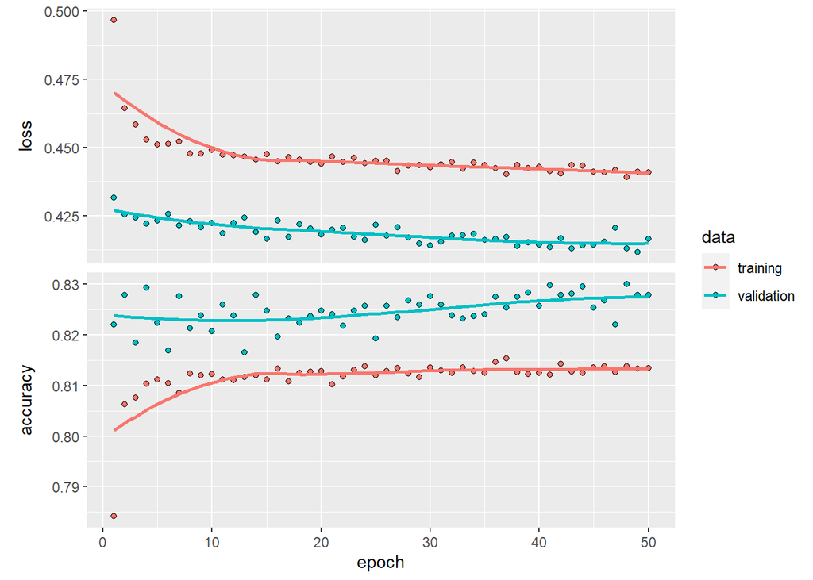

```r
plot(history)
```

### Final results and saved model

```r
#Saved model
save_model_tf(model, "GILHERNANDEZ")

history
```

```
##
## Final epoch (plot to see history):
##         loss: 0.4409
##     accuracy: 0.8135
##     val_loss: 0.4166
## val_accuracy: 0.8279
```

```r
metrics <- model %>% evaluate(x_test, y_test)
```

```
## 185/185 - 0s - loss: 0.4458 - accuracy: 0.8111 - 89ms/epoch - 483us/step
```

```r
metrics
```

```
##      loss  accuracy
## 0.4458294 0.8110583
```

## Conclusion

##### Early stopping is a regularization technique employed during the training phase. By monitoring the model’s performance on a validation set, early stopping allows us to halt the training process when the model’s performance starts to degrade, preventing overfitting. This method helps strike a balance between achieving good training accuracy and avoiding the risk of overfitting to the training data.

##### The dropout technique is another regularization method that involves randomly deactivating a certain percentage of neurons during each training iteration. This helps prevent co-adaptation of hidden units and promotes robustness in the model. By introducing dropout layers in our neural network architecture, we have witnessed the positive impact on generalization performance. Dropout has proven to be an effective means of reducing overfitting, particularly in scenarios where the model exhibits high complexity or when working with limited amounts of data.

##### The FLAG function allowed us to make several experiments in order to identify the best and more efficient scenario trying different optimizers and neuron units. However it can be concluded that the best model is not the one with the biggest amount of neurons of that uses and specific optimized.